# BreastCancer_metabolomicsProfiling

Ujjalkumar Das

2026-07-28

## Preparing environment

```r
library(tidyverse)
```

```r
library(dplyr)
library(tidyr)
library(purrr)
library(stringr)
library(ggplot2)
library(readr)
library(tibble)
library(gridExtra)
```

## Loading lcms data

```r
lcms_data <- read_tsv("MSdata_ST000355_AN000581.txt", col_names = TRUE, show_col_types = TRUE)
lcms_data
```

```
## # A tibble: 100 × 212
##    Samples       PN01935 PN02020 PN02212 PN02261 PN02307 PN02394 PN02453 PN02523
##    <chr>         <chr>   <chr>   <chr>   <chr>   <chr>   <chr>   <chr>   <chr>
##  1 Factors       Diagno… Diagno… Diagno… Diagno… Diagno… Diagno… Diagno… Diagno…
##  2 18-Hydroxyco… 0.0162  0.0153  0.0136  0.0064  0.0133  0.0080  0.0112  0.0107
##  3 1-Pyrroline-… 0.2309  0.2990  0.3401  0.2464  0.2286  0.2915  0.3069  0.2282
##  4 2_3-Diaminop… 0.1919  0.2138  0.1488  0.1375  0.1432  0.1556  0.1135  0.1255
##  5 2-Hydroxycin… 0.0161  0.0206  0.0146  0.0188  0.0172  0.0305  0.0134  0.0182
##  6 3-Hydroxydod… 0.2655  0.0113  0.0276  0.0091  0.0785  0.0077  0.0275  0.0292
##  7 3-Indoleprop… 0.0225  0.0045  0.0186  0.0048  0.0021  0.0037  0.0248  0.0067
##  8 3-Pyridylace… 0.0092  0.1703  0.0244  0.0932  0.0146  0.0896  0.1868  0.0477
##  9 3-Succinoylp… 0.0202  0.1031  0.0251  0.0165  0.0205  0.0758  0.0385  0.0342
## 10 4_8 dimethyl… 0.0118  0.0154  0.0167  0.0104  0.0032  0.0088  0.0095  0.0076
## # ℹ 90 more rows
## # ℹ 203 more variables: PN02528 <chr>, PN02546 <chr>, PN02619 <chr>,
## #   PN02637 <chr>, PN02760 <chr>, PN02773 <chr>, PN02791 <chr>, PN02854 <chr>,
## #   PN02917 <chr>, PN02944 <chr>, PN02956 <chr>, PN00023 <chr>, PN00025 <chr>,
## #   PN00029 <chr>, PN00031 <chr>, PN00032 <chr>, PN00033 <chr>, PN00038 <chr>,
## #   PN00272 <chr>, PN00373 <chr>, PN00414 <chr>, PN00427 <chr>, PN00443 <chr>,
## #   PN00465 <chr>, PN00468 <chr>, PN00481 <chr>, PN00482 <chr>, …
```

## Separating sample metadata (Diagnosis, Stage) from the metabolite matrix

The “Factors” row packs `Diagnosis` and `Stage` into a single string per sample (e.g. `Diagnosis:Breast cancer | Stage:1`). Pull it into its own metadata table, then drop it from `lcms_data` so the remaining rows are all metabolite abundances.

```r
sample_metadata <- lcms_data |>
  filter(Samples == "Factors") |>
  select(-Samples) |>
  pivot_longer(everything(), names_to = "sample_id", values_to = "factor_string") |>
  mutate(
    Diagnosis = str_extract(factor_string, "(?<=Diagnosis:)[^|]+") |> str_trim(),
    Stage     = str_extract(factor_string, "(?<=Stage:)[^|]+") |> str_trim()
  ) |>
  select(sample_id, Diagnosis, Stage)

lcms_data_abundances <- lcms_data |>
  filter(Samples != "Factors") |>
  rename(Compound = Samples)

sample_metadata
```

```
## # A tibble: 211 × 3
##    sample_id Diagnosis     Stage
##    <chr>     <chr>         <chr>
##  1 PN01935   Breast cancer 1
##  2 PN02020   Breast cancer 1
##  3 PN02212   Breast cancer 1
##  4 PN02261   Breast cancer 1
##  5 PN02307   Breast cancer 1
##  6 PN02394   Breast cancer 1
##  7 PN02453   Breast cancer 1
##  8 PN02523   Breast cancer 1
##  9 PN02528   Breast cancer 1
## 10 PN02546   Breast cancer 1
## # ℹ 201 more rows
```

```r
sample_metadata |>
  count(Stage) |> print()
```

```
## # A tibble: 5 × 2
##   Stage     n
##   <chr> <int>
## 1 -        76
## 2 1        19
## 3 2        49
## 4 3        47
## 5 4        20
```

```r
lcms_data_abundances
```

```
## # A tibble: 99 × 212
##    Compound      PN01935 PN02020 PN02212 PN02261 PN02307 PN02394 PN02453 PN02523
##    <chr>         <chr>   <chr>   <chr>   <chr>   <chr>   <chr>   <chr>   <chr>
##  1 18-Hydroxyco… 0.0162  0.0153  0.0136  0.0064  0.0133  0.0080  0.0112  0.0107
##  2 1-Pyrroline-… 0.2309  0.2990  0.3401  0.2464  0.2286  0.2915  0.3069  0.2282
##  3 2_3-Diaminop… 0.1919  0.2138  0.1488  0.1375  0.1432  0.1556  0.1135  0.1255
##  4 2-Hydroxycin… 0.0161  0.0206  0.0146  0.0188  0.0172  0.0305  0.0134  0.0182
##  5 3-Hydroxydod… 0.2655  0.0113  0.0276  0.0091  0.0785  0.0077  0.0275  0.0292
##  6 3-Indoleprop… 0.0225  0.0045  0.0186  0.0048  0.0021  0.0037  0.0248  0.0067
##  7 3-Pyridylace… 0.0092  0.1703  0.0244  0.0932  0.0146  0.0896  0.1868  0.0477
##  8 3-Succinoylp… 0.0202  0.1031  0.0251  0.0165  0.0205  0.0758  0.0385  0.0342
##  9 4_8 dimethyl… 0.0118  0.0154  0.0167  0.0104  0.0032  0.0088  0.0095  0.0076
## 10 4-Aminohippu… 0.0449  0.0305  0.0310  0.0211  0.0334  0.0353  0.0382  0.0315
## # ℹ 89 more rows
## # ℹ 203 more variables: PN02528 <chr>, PN02546 <chr>, PN02619 <chr>,
## #   PN02637 <chr>, PN02760 <chr>, PN02773 <chr>, PN02791 <chr>, PN02854 <chr>,
## #   PN02917 <chr>, PN02944 <chr>, PN02956 <chr>, PN00023 <chr>, PN00025 <chr>,
## #   PN00029 <chr>, PN00031 <chr>, PN00032 <chr>, PN00033 <chr>, PN00038 <chr>,
## #   PN00272 <chr>, PN00373 <chr>, PN00414 <chr>, PN00427 <chr>, PN00443 <chr>,
## #   PN00465 <chr>, PN00468 <chr>, PN00481 <chr>, PN00482 <chr>, …
```

## Cross-checking against metadata.csv

`metadata.csv` provides Diagnosis/Stage independently (via `Sample name`). Join it to `sample_metadata` and check agreement.

```r
metadata_csv <- read_csv("metadata.csv", show_col_types = FALSE)
metadata_csv
```

```
## # A tibble: 211 × 18
##    mb_sample_id `Subject name` `Sample name` Diagnosis     Stage
##    <chr>        <chr>          <chr>         <chr>         <chr>
##  1 SA015540     -              PN01935       Breast cancer 1
##  2 SA015541     -              PN02020       Breast cancer 1
##  3 SA015551     -              PN02212       Breast cancer 1
##  4 SA015543     -              PN02261       Breast cancer 1
##  5 SA015537     -              PN02307       Breast cancer 1
##  6 SA015536     -              PN02394       Breast cancer 1
##  7 SA015546     -              PN02453       Breast cancer 1
##  8 SA015553     -              PN02523       Breast cancer 1
##  9 SA015544     -              PN02528       Breast cancer 1
## 10 SA015538     -              PN02546       Breast cancer 1
## # ℹ 201 more rows
## # ℹ 13 more variables: `Sample_Data:Sub-group` <chr>,
## #   Clinical_Parameters <dbl>, ER <chr>, PR <chr>, `HER-2 neu` <chr>,
## #   YOB <chr>, `Age (now)` <dbl>, `Age (BOD-OD)` <dbl>, Race <chr>,
## #   `Stage OB` <chr>, BMI <dbl>, `Year of Sample Collection` <chr>,
## #   `Prog/Relapse by 9/7/11` <chr>
```

```r
metadata_merged <- sample_metadata |>
  inner_join(metadata_csv, by = c("sample_id" = "Sample name")) |>
  mutate(
    diagnosis_match = Diagnosis.x == Diagnosis.y,
    stage_match = as.character(Stage.x) == as.character(Stage.y)
  )

nrow(sample_metadata)
```

```
## [1] 211
```

```r
nrow(metadata_csv)
```

```
## [1] 211
```

```r
nrow(metadata_merged)
```

```
## [1] 211
```

```r
metadata_merged |> count(diagnosis_match)
```

```
## # A tibble: 1 × 2
##   diagnosis_match     n
##   <lgl>           <int>
## 1 TRUE              211
```

```r
metadata_merged |> count(stage_match)
```

```
## # A tibble: 1 × 2
##   stage_match     n
##   <lgl>       <int>
## 1 TRUE          211
```

```r
metadata_merged
```

```
## # A tibble: 211 × 22
##    sample_id Diagnosis.x Stage.x mb_sample_id `Subject name` Diagnosis.y Stage.y
##    <chr>     <chr>       <chr>   <chr>        <chr>          <chr>       <chr>
##  1 PN01935   Breast can… 1       SA015540     -              Breast can… 1
##  2 PN02020   Breast can… 1       SA015541     -              Breast can… 1
##  3 PN02212   Breast can… 1       SA015551     -              Breast can… 1
##  4 PN02261   Breast can… 1       SA015543     -              Breast can… 1
##  5 PN02307   Breast can… 1       SA015537     -              Breast can… 1
##  6 PN02394   Breast can… 1       SA015536     -              Breast can… 1
##  7 PN02453   Breast can… 1       SA015546     -              Breast can… 1
##  8 PN02523   Breast can… 1       SA015553     -              Breast can… 1
##  9 PN02528   Breast can… 1       SA015544     -              Breast can… 1
## 10 PN02546   Breast can… 1       SA015538     -              Breast can… 1
## # ℹ 201 more rows
## # ℹ 15 more variables: `Sample_Data:Sub-group` <chr>,
## #   Clinical_Parameters <dbl>, ER <chr>, PR <chr>, `HER-2 neu` <chr>,
## #   YOB <chr>, `Age (now)` <dbl>, `Age (BOD-OD)` <dbl>, Race <chr>,
## #   `Stage OB` <chr>, BMI <dbl>, `Year of Sample Collection` <chr>,
## #   `Prog/Relapse by 9/7/11` <chr>, diagnosis_match <lgl>, stage_match <lgl>
```

```r
View(metadata_merged)
```

## polishing merged metadata

```r
metadata_merged <-
  metadata_merged |>
  rename(Stage = Stage.x, Diagnosis = Diagnosis.x) |>
  select(-ends_with(c(".y", "_match")), -`Subject name`, -`Sample_Data:Sub-group`)

metadata_merged$Stage <- as.factor(metadata_merged$Stage)
metadata_merged
```

```
## # A tibble: 211 × 16
##    sample_id Diagnosis     Stage mb_sample_id Clinical_Parameters ER    PR
##    <chr>     <chr>         <fct> <chr>                      <dbl> <chr> <chr>
##  1 PN01935   Breast cancer 1     SA015540                      32 1     1
##  2 PN02020   Breast cancer 1     SA015541                      41 -     1
##  3 PN02212   Breast cancer 1     SA015551                      64 1     -
##  4 PN02261   Breast cancer 1     SA015543                     193 -     -
##  5 PN02307   Breast cancer 1     SA015537                     124 1     1
##  6 PN02394   Breast cancer 1     SA015536                     133 1     1
##  7 PN02453   Breast cancer 1     SA015546                     156 -     -
##  8 PN02523   Breast cancer 1     SA015553                     216 1     1
##  9 PN02528   Breast cancer 1     SA015544                     110 -     -
## 10 PN02546   Breast cancer 1     SA015538                       9 1     1
## # ℹ 201 more rows
## # ℹ 9 more variables: `HER-2 neu` <chr>, YOB <chr>, `Age (now)` <dbl>,
## #   `Age (BOD-OD)` <dbl>, Race <chr>, `Stage OB` <chr>, BMI <dbl>,
## #   `Year of Sample Collection` <chr>, `Prog/Relapse by 9/7/11` <chr>
```

## Long-format metabolite table for exploratory plots

Pivot `lcms_data_abundances` into long format (one row per compound × sample) and join with `metadata_merged` so Diagnosis/Stage are available for plotting.

```r
lcms_long <- lcms_data_abundances |>
  pivot_longer(-Compound, names_to = "sample_id", values_to = "abundance") |>
  mutate(abundance = as.numeric(abundance)) |>
  left_join(metadata_merged, by = "sample_id")
lcms_long
```

```
## # A tibble: 20,889 × 18
##    Compound sample_id abundance Diagnosis Stage mb_sample_id Clinical_Parameters
##    <chr>    <chr>         <dbl> <chr>     <fct> <chr>                      <dbl>
##  1 18-Hydr… PN01935      0.0162 Breast c… 1     SA015540                      32
##  2 18-Hydr… PN02020      0.0153 Breast c… 1     SA015541                      41
##  3 18-Hydr… PN02212      0.0136 Breast c… 1     SA015551                      64
##  4 18-Hydr… PN02261      0.0064 Breast c… 1     SA015543                     193
##  5 18-Hydr… PN02307      0.0133 Breast c… 1     SA015537                     124
##  6 18-Hydr… PN02394      0.008  Breast c… 1     SA015536                     133
##  7 18-Hydr… PN02453      0.0112 Breast c… 1     SA015546                     156
##  8 18-Hydr… PN02523      0.0107 Breast c… 1     SA015553                     216
##  9 18-Hydr… PN02528      0.0114 Breast c… 1     SA015544                     110
## 10 18-Hydr… PN02546      0.0053 Breast c… 1     SA015538                       9
## # ℹ 20,879 more rows
## # ℹ 11 more variables: ER <chr>, PR <chr>, `HER-2 neu` <chr>, YOB <chr>,
## #   `Age (now)` <dbl>, `Age (BOD-OD)` <dbl>, Race <chr>, `Stage OB` <chr>,
## #   BMI <dbl>, `Year of Sample Collection` <chr>,
## #   `Prog/Relapse by 9/7/11` <chr>
```

```r
# 146 of ~20,900 compound x sample values are missing in the source data
sum(is.na(lcms_long$abundance))
```

```
## [1] 146
```

```r
lcms_long
```

```
## # A tibble: 20,889 × 18
##    Compound sample_id abundance Diagnosis Stage mb_sample_id Clinical_Parameters
##    <chr>    <chr>         <dbl> <chr>     <fct> <chr>                      <dbl>
##  1 18-Hydr… PN01935      0.0162 Breast c… 1     SA015540                      32
##  2 18-Hydr… PN02020      0.0153 Breast c… 1     SA015541                      41
##  3 18-Hydr… PN02212      0.0136 Breast c… 1     SA015551                      64
##  4 18-Hydr… PN02261      0.0064 Breast c… 1     SA015543                     193
##  5 18-Hydr… PN02307      0.0133 Breast c… 1     SA015537                     124
##  6 18-Hydr… PN02394      0.008  Breast c… 1     SA015536                     133
##  7 18-Hydr… PN02453      0.0112 Breast c… 1     SA015546                     156
##  8 18-Hydr… PN02523      0.0107 Breast c… 1     SA015553                     216
##  9 18-Hydr… PN02528      0.0114 Breast c… 1     SA015544                     110
## 10 18-Hydr… PN02546      0.0053 Breast c… 1     SA015538                       9
## # ℹ 20,879 more rows
## # ℹ 11 more variables: ER <chr>, PR <chr>, `HER-2 neu` <chr>, YOB <chr>,
## #   `Age (now)` <dbl>, `Age (BOD-OD)` <dbl>, Race <chr>, `Stage OB` <chr>,
## #   BMI <dbl>, `Year of Sample Collection` <chr>,
## #   `Prog/Relapse by 9/7/11` <chr>
```

## Heatmap of metabolite abundances by Stage

Mean abundance per compound is computed for each Stage, then z-scored within each compound (row) so all 99 compounds — despite very different absolute scales — are visually comparable. Compounds are ordered by hierarchical clustering to group similar Stage-response patterns together.

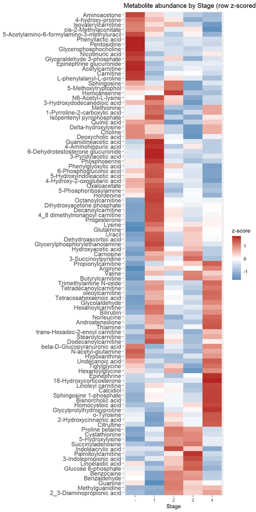

```r
heatmap_data <- lcms_long |>
  group_by(Compound, Stage) |>
  summarise(mean_abundance = mean(abundance, na.rm = TRUE), .groups = "drop") |>
  group_by(Compound) |>
  mutate(z = as.numeric(scale(mean_abundance))) |>
  ungroup()

clust_matrix <- heatmap_data |>
  select(Compound, Stage, z) |>
  pivot_wider(names_from = Stage, values_from = z) |>
  column_to_rownames("Compound") |>
  as.matrix()

compound_order <- rownames(clust_matrix)[hclust(dist(clust_matrix))$order]

heatmap_data <- heatmap_data |>
  mutate(Compound = factor(Compound, levels = compound_order))

ggplot(heatmap_data, aes(x = Stage, y = Compound, fill = z)) +
  geom_tile() +
  scale_fill_gradient2(low = "steelblue", mid = "white", high = "firebrick", midpoint = 0) +
  labs(title = "Metabolite abundance by Stage (row z-scored)",
       x = "Stage", y = NULL, fill = "z-score") +
  theme(axis.text.y = element_text(size = 12))
```

## One-way ANOVA per compound across Diagnosis/Stage groups

`Stage` has 5 levels: `-` (Control, n = 76) and cancer Stages 1-4 (n = 19, 49, 47, 20). For each of the 99 compounds we fit a one-way ANOVA of log2-transformed abundance on `Stage`, then correct the 99 resulting p-values for multiple testing with the Benjamini-Hochberg (FDR) method.

Abundances include exact zeros, so a small pseudocount (half the smallest observed non-zero abundance) is added before log-transforming.

```r
library(broom)

min_pos <- min(lcms_long$abundance[lcms_long$abundance > 0], na.rm = TRUE)

lcms_long_log <- lcms_long |>
  mutate(log_abundance = log2(abundance + min_pos / 2))

anova_results <- lcms_long_log |>
  group_by(Compound) |>
  nest() |>
  mutate(
    model = map(data, ~ aov(log_abundance ~ Stage, data = .x)),
    tidy_model = map(model, broom::tidy)
  ) |>
  select(Compound, tidy_model) |>
  unnest(tidy_model) |>
  filter(term == "Stage") |>
  ungroup() |>
  mutate(p_adj_BH = p.adjust(p.value, method = "BH")) |>
  arrange(p_adj_BH)

anova_results |> select(Compound, df, statistic, p.value, p_adj_BH)
```

```
## # A tibble: 99 × 5
##    Compound                   df statistic  p.value p_adj_BH
##    <chr>                   <dbl>     <dbl>    <dbl>    <dbl>
##  1 Glycerophosphocholine       4     56.1  5.77e-32 5.71e-30
##  2 Pentosidine                 4     32.9  1.88e-20 9.29e-19
##  3 Glutamine                   4     30.3  8.30e-20 2.74e-18
##  4 Phenyllactic acid           4     16.9  5.83e-12 1.44e-10
##  5 Lysine                      4     16.0  2.04e-11 4.04e-10
##  6 Linoleyl carnitine          4     10.1  1.79e- 7 2.96e- 6
##  7 Bilirubin                   4      9.56 4.12e- 7 5.83e- 6
##  8 Sphingosine 1-phosphate     4      8.78 1.46e- 6 1.81e- 5
##  9 3-Indolepropionic acid      4      7.92 5.86e- 6 5.80e- 5
## 10 Bisnorcholic acid           4      7.94 5.68e- 6 5.80e- 5
## # ℹ 89 more rows
```

```r
sum(anova_results$p_adj_BH < 0.05)
```

```
## [1] 42
```

### Why log-transform? Skewness before and after

Raw abundances are right-skewed for most compounds, which motivates the log2-transformation used above. We quantify skewness per compound on the raw scale and on the log2 scale to confirm the transform actually reduces it.

```r
skewness_fn <- function(x) {
  x <- x[!is.na(x)]
  n <- length(x)
  (sum((x - mean(x))^3) / n) / sd(x)^3
}

skew_compare <- lcms_long_log |>
  group_by(Compound) |>
  summarise(
    skewness_raw = skewness_fn(abundance),
    skewness_log = skewness_fn(log_abundance),
    .groups = "drop"
  )

summary(skew_compare$skewness_raw)
```

```
##    Min. 1st Qu.  Median    Mean 3rd Qu.    Max.
##  -1.755   0.908   1.780   2.378   3.078  13.261
```

```r
summary(skew_compare$skewness_log)
```

```
##     Min.  1st Qu.   Median     Mean  3rd Qu.     Max.
## -6.27224 -0.55722 -0.06344 -0.37398  0.30465  2.11259
```

```r
# How many compounds are "highly skewed" (|skewness| > 1) on each scale
sum(abs(skew_compare$skewness_raw) > 1, na.rm = TRUE)
```

```
## [1] 74
```

```r
sum(abs(skew_compare$skewness_log) > 1, na.rm = TRUE)
```

```
## [1] 28
```

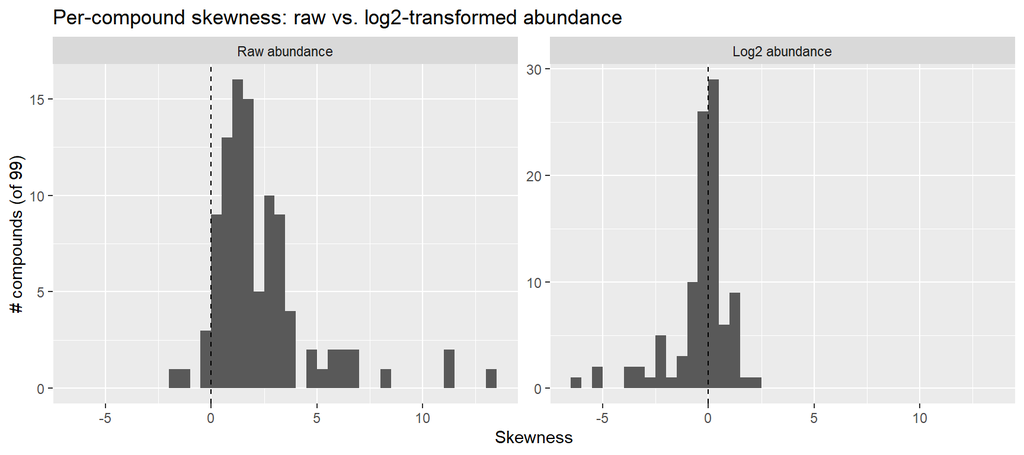

```r
skew_compare_long <- skew_compare |>
  pivot_longer(starts_with("skewness"), names_to = "scale", values_to = "skewness") |>
  mutate(scale = recode(scale, skewness_raw = "Raw abundance", skewness_log = "Log2 abundance"),
         scale = factor(scale, levels = c("Raw abundance", "Log2 abundance")))

ggplot(skew_compare_long, aes(x = skewness)) +
  geom_histogram(binwidth = 0.5, boundary = 0) +
  geom_vline(xintercept = 0, linetype = "dashed") +
  facet_wrap(~scale, scales = "free_y") +
  labs(title = "Per-compound skewness: raw vs. log2-transformed abundance",
       x = "Skewness", y = "# compounds (of 99)")
```

Raw abundances are overwhelmingly right-skewed: median skewness is 1.78, and 74 of 99 compounds have |skewness| > 1, almost all in the positive (right-skewed) direction. On the log2 scale, median skewness moves close to zero (-0.06) and only 28 of 99 compounds remain highly skewed (a mix of residual right- and left-skew). Log2-transforming substantially reduces skewness overall – supporting its use as the working scale for the ANOVA, Tukey, and correlation analyses above – though it does not fully normalize every compound, consistent with the non-normal residuals noted in the assumption checks below.

### Checking ANOVA assumptions

```r
library(car)
```

```r
anova_diag <- lcms_long_log |>
  group_by(Compound) |>
  nest() |>
  mutate(
    model = map(data, ~ aov(log_abundance ~ Stage, data = .x)),
    shapiro_p = map_dbl(model, ~ shapiro.test(residuals(.x))$p.value),
    levene_p = map_dbl(data, ~ tryCatch(
      leveneTest(log_abundance ~ Stage, data = .x)[1, "Pr(>F)"],
      error = function(e) NA_real_
    ))
  ) |>
  select(Compound, shapiro_p, levene_p) |>
  ungroup()

# Residuals are non-normal for many compounds even after log transform;
# a meaningful fraction also show unequal variance across groups.
cat("Non-normal residuals (Shapiro p < .05):", sum(anova_diag$shapiro_p < 0.05), "/", nrow(anova_diag), "\n")
```

```
## Non-normal residuals (Shapiro p < .05): 63 / 99
```

```r
cat("Unequal variances (Levene p < .05):    ", sum(anova_diag$levene_p < 0.05, na.rm = TRUE), "/", sum(!is.na(anova_diag$levene_p)), "\n")
```

```
## Unequal variances (Levene p < .05):     22 / 99
```

Given the unequal variances flagged above (driven partly by the unbalanced group sizes), we cross-check with Welch’s ANOVA, which does not assume equal variances.

```r
welch_results <- lcms_long_log |>
  group_by(Compound) |>
  nest() |>
  mutate(
    welch = map(data, ~ oneway.test(log_abundance ~ Stage, data = .x, var.equal = FALSE)),
    statistic = map_dbl(welch, "statistic"),
    p.value = map_dbl(welch, "p.value")
  ) |>
  select(Compound, statistic, p.value) |>
  ungroup() |>
  mutate(p_adj_BH = p.adjust(p.value, method = "BH")) |>
  arrange(p_adj_BH)

# Agreement between standard-ANOVA and Welch-ANOVA significance calls
# (rows = standard ANOVA sig., columns = Welch ANOVA sig.)
compare_sig <- anova_results |>
  select(Compound, p_adj_BH_std = p_adj_BH) |>
  left_join(welch_results |> select(Compound, p_adj_BH_welch = p_adj_BH), by = "Compound") |>
  mutate(sig_std = p_adj_BH_std < 0.05, sig_welch = p_adj_BH_welch < 0.05)

table(standard = compare_sig$sig_std, welch = compare_sig$sig_welch)
```

```
##         welch
## standard FALSE TRUE
##    FALSE    55    2
##    TRUE      2   40
```

The two approaches agree on the vast majority of compounds, so the ANOVA conclusions are not driven by the variance-homogeneity violation.

### Significant compounds (BH-adjusted p < 0.05)

```r
sig_compounds <- anova_results |>
  filter(p_adj_BH < 0.05)

nrow(sig_compounds)
```

```
## [1] 42
```

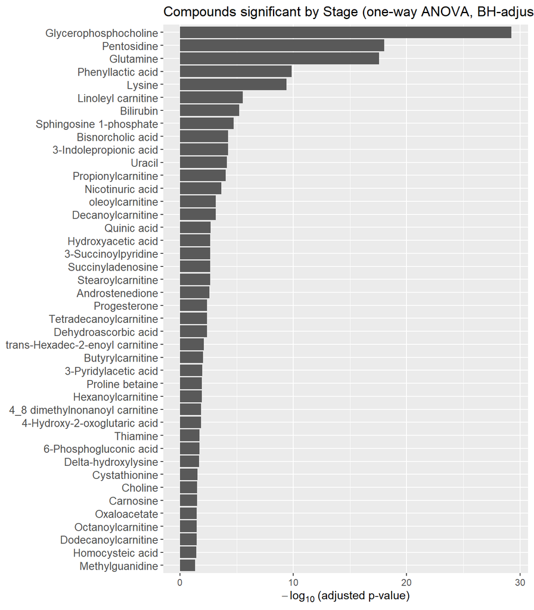

```r
ggplot(sig_compounds, aes(x = -log10(p_adj_BH), y = reorder(Compound, -log10(p_adj_BH)))) +
  geom_col() +
  labs(title = "Compounds significant by Stage (one-way ANOVA, BH-adjusted)",
       x = expression(-log[10]~ "(adjusted p-value)"), y = NULL) +
  theme(axis.text.y = element_text(size = 10))
```

## Tukey HSD post-hoc tests on ANOVA-significant compounds

The omnibus ANOVA only tells us a compound differs *somewhere* across the 5 groups. For the 42 compounds significant at BH-adjusted p < 0.05, Tukey HSD identifies *which* pairs of groups (Control, Stage 1-4) differ, with the family-wise error rate controlled within each compound’s set of 10 pairwise comparisons.

```r
sig_compound_names <- anova_results |> filter(p_adj_BH < 0.05) |> pull(Compound)

tukey_results <- lcms_long_log |>
  filter(Compound %in% sig_compound_names) |>
  group_by(Compound) |>
  nest() |>
  mutate(
    model = map(data, ~ aov(log_abundance ~ Stage, data = .x)),
    tukey = map(model, ~ broom::tidy(TukeyHSD(.x)))
  ) |>
  select(Compound, tukey) |>
  unnest(tukey) |>
  ungroup() |>
  select(Compound, contrast, estimate, adj.p.value)

tukey_results
```

```
## # A tibble: 420 × 4
##    Compound               contrast estimate adj.p.value
##    <chr>                  <chr>       <dbl>       <dbl>
##  1 3-Indolepropionic acid 1--        1.23     0.00984
##  2 3-Indolepropionic acid 2--        1.12     0.000386
##  3 3-Indolepropionic acid 3--        1.29     0.0000345
##  4 3-Indolepropionic acid 4--        0.761    0.232
##  5 3-Indolepropionic acid 2-1       -0.113    0.999
##  6 3-Indolepropionic acid 3-1        0.0563   1.000
##  7 3-Indolepropionic acid 4-1       -0.471    0.849
##  8 3-Indolepropionic acid 3-2        0.169    0.979
##  9 3-Indolepropionic acid 4-2       -0.359    0.885
## 10 3-Indolepropionic acid 4-3       -0.528    0.654
## # ℹ 410 more rows
```

### Which group pairs drive the differences?

```r
# Contrasts ending "--" involve Control (Stage level "-");
# all others compare two cancer stages.
contrast_summary <- tukey_results |>
  group_by(contrast) |>
  summarise(n_sig = sum(adj.p.value < 0.05), n_total = n(), .groups = "drop") |>
  mutate(contrast_type = ifelse(grepl("--$", contrast), "vs Control", "Stage vs Stage")) |>
  arrange(desc(n_sig))

contrast_summary |> print()
```

```
## # A tibble: 10 × 4
##    contrast n_sig n_total contrast_type
##    <chr>    <int>   <int> <chr>
##  1 1--         25      42 vs Control
##  2 3--         22      42 vs Control
##  3 2--         21      42 vs Control
##  4 4--         18      42 vs Control
##  5 3-1          5      42 Stage vs Stage
##  6 4-3          4      42 Stage vs Stage
##  7 4-2          3      42 Stage vs Stage
##  8 2-1          2      42 Stage vs Stage
##  9 4-1          1      42 Stage vs Stage
## 10 3-2          0      42 Stage vs Stage
```

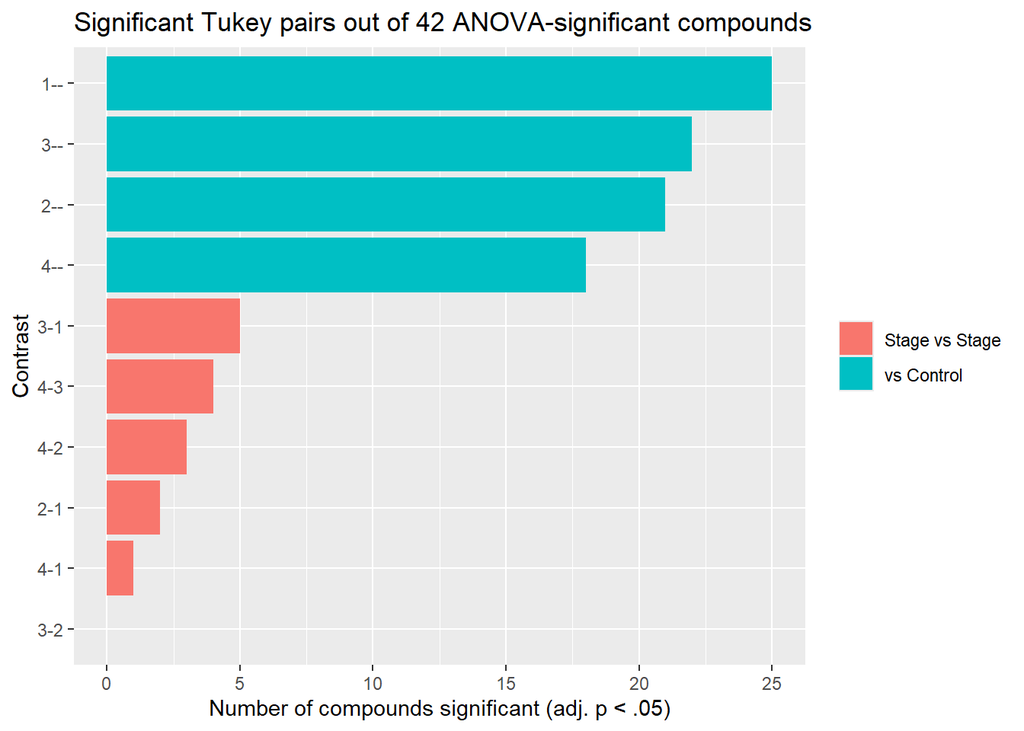

```r
ggplot(contrast_summary, aes(x = n_sig, y = reorder(contrast, n_sig), fill = contrast_type)) +
  geom_col() +
  labs(title = "Significant Tukey pairs out of 42 ANOVA-significant compounds",
       x = "Number of compounds significant (adj. p < .05)", y = "Contrast", fill = NULL)
```

Differences are concentrated in the **Control vs. cancer** comparisons (18-25 of 42 compounds significant for each Stage-vs-Control pair), while **Stage-vs-Stage** comparisons among cancer cases are rarely significant (0-5 of 42). This suggests the ANOVA signal detected above is driven mainly by cancer-vs-healthy differences rather than progression across cancer stages.

### Compounds with a significant Stage-vs-Stage difference

```r
tukey_results |>
  filter(!grepl("--$", contrast), adj.p.value < 0.05) |>
  arrange(adj.p.value) |> arrange(contrast) |>
  print()
```

```
## # A tibble: 15 × 4
##    Compound                        contrast estimate adj.p.value
##    <chr>                           <chr>       <dbl>       <dbl>
##  1 3-Pyridylacetic acid            2-1        -1.41     0.0168
##  2 Androstenedione                 2-1        -0.657    0.0241
##  3 trans-Hexadec-2-enoyl carnitine 3-1        -0.739    0.00671
##  4 3-Pyridylacetic acid            3-1        -1.40     0.0193
##  5 Decanoylcarnitine               3-1        -0.925    0.0252
##  6 Dodecanoylcarnitine             3-1        -0.664    0.0301
##  7 Progesterone                    3-1        -0.623    0.0401
##  8 6-Phosphogluconic acid          4-1        -0.332    0.0126
##  9 Androstenedione                 4-2         0.770    0.00364
## 10 Quinic acid                     4-2         0.366    0.0297
## 11 Linoleyl carnitine              4-2         0.531    0.0437
## 12 Linoleyl carnitine              4-3         0.818    0.000265
## 13 Androstenedione                 4-3         0.695    0.0126
## 14 oleoylcarnitine                 4-3         0.552    0.0287
## 15 Sphingosine 1-phosphate         4-3         0.539    0.0414
```

## Clustered correlation analysis of compounds

Using `lcms_long_log` (log2 abundance for all 99 compounds x 211 samples), we compute pairwise **Spearman** correlations between compounds (Spearman rather than Pearson given the non-normality documented above) and cluster compounds by correlation structure (distance = 1 - correlation, average linkage).

```r
library(tidyr)
library(tibble)

log_wide <- lcms_long_log |>
  select(Compound, sample_id, log_abundance) |>
  pivot_wider(names_from = sample_id, values_from = log_abundance) |>
  column_to_rownames("Compound") |>
  as.matrix()

cor_mat <- cor(t(log_wide), method = "spearman", use = "pairwise.complete.obs")
cor_dist <- as.dist(1 - cor_mat)
hc <- hclust(cor_dist, method = "average")
```

### Choosing the number of clusters

Average silhouette width is used to check whether the data support distinct compound clusters, rather than picking a cluster count arbitrarily.

```r
library(cluster)

sil_widths <- sapply(2:15, function(k) {
  cl <- cutree(hc, k = k)
  mean(silhouette(cl, cor_dist)[, "sil_width"])
})

data.frame(k = 2:15, avg_sil_width = round(sil_widths, 3))
```

```
##     k avg_sil_width
## 1   2         0.156
## 2   3         0.104
## 3   4         0.098
## 4   5         0.122
## 5   6         0.130
## 6   7         0.130
## 7   8         0.148
## 8   9         0.142
## 9  10         0.134
## 10 11         0.162
## 11 12         0.170
## 12 13         0.166
## 13 14         0.187
## 14 15         0.202
```

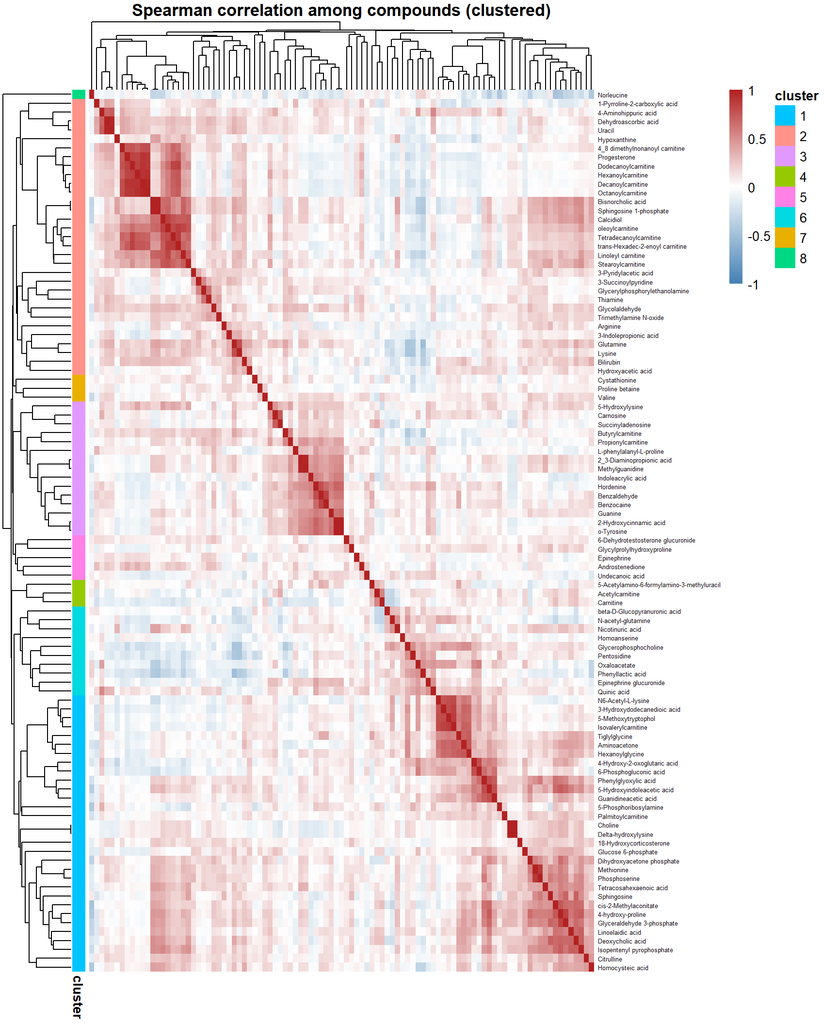

```r
library(pheatmap)

k_clusters <- 8
cluster_assignments <- cutree(hc, k = k_clusters)
annotation_row <- data.frame(cluster = factor(cluster_assignments))
rownames(annotation_row) <- names(cluster_assignments)

pheatmap(
  cor_mat,
  clustering_distance_rows = cor_dist,
  clustering_distance_cols = cor_dist,
  clustering_method = "average",
  annotation_row = annotation_row,
  show_colnames = FALSE,
  fontsize_row = 5,
  main = "Spearman correlation among compounds (clustered)",
  color = colorRampPalette(c("steelblue", "white", "firebrick"))(100),
  breaks = seq(-1, 1, length.out = 101)
)
```

Most off-diagonal correlations are weak (near white), consistent with the low silhouette widths; a couple of tighter, more strongly-correlated sub-blocks are visible nested within the larger clusters, which may be worth inspecting individually (e.g. by compound class such as acylcarnitines).

## Sample-sample correlation, annotated by Stage

The compound-compound clustering above asks whether *compounds* group together. Here we instead ask whether *samples* cluster by Stage: do patients with the same Stage (or Control) have more similar overall metabolite profiles than patients in different Stages?

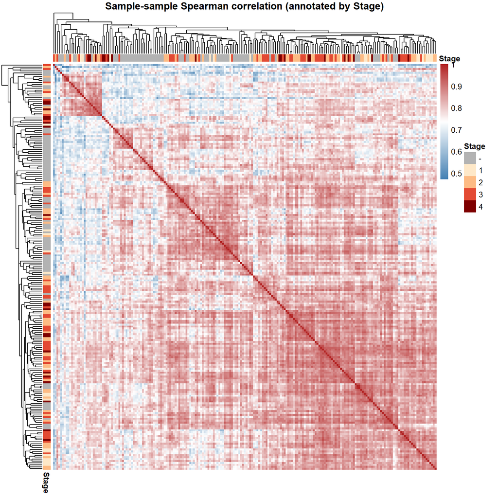

```r
library(tibble)

sample_cor <- cor(log_wide, method = "spearman", use = "pairwise.complete.obs")
sample_dist <- as.dist(1 - sample_cor)
hc_samples <- hclust(sample_dist, method = "average")

stage_annotation <- metadata_merged |>
  select(sample_id, Stage) |>
  distinct() |>
  column_to_rownames("sample_id")
stage_annotation <- stage_annotation[colnames(sample_cor), , drop = FALSE]

stage_colors <- list(Stage = c(
  "-" = "grey70", "1" = "#fee8c8", "2" = "#fdbb84", "3" = "#e34a33", "4" = "#7f0000"
))

pheatmap(
  sample_cor,
  clustering_distance_rows = sample_dist,
  clustering_distance_cols = sample_dist,
  clustering_method = "average",
  annotation_row = stage_annotation,
  annotation_col = stage_annotation,
  annotation_colors = stage_colors,
  show_rownames = FALSE,
  show_colnames = FALSE,
  main = "Sample-sample Spearman correlation (annotated by Stage)",
  color = colorRampPalette(c("steelblue", "white", "firebrick"))(100),
  breaks = seq(min(sample_cor), 1, length.out = 101)
)
```

Visually the Stage color bar does not resolve into distinct blocks along the dendrogram, suggesting Stage is not a dominant driver of overall sample similarity. We quantify this directly by comparing mean pairwise correlation for same-Stage vs. different-Stage sample pairs.

```r
cor_long <- as.data.frame(sample_cor) |>
  rownames_to_column("sample_a") |>
  pivot_longer(-sample_a, names_to = "sample_b", values_to = "r") |>
  filter(sample_a != sample_b) |>
  left_join(stage_annotation |> rownames_to_column("sample_a") |> rename(stage_a = Stage), by = "sample_a") |>
  left_join(stage_annotation |> rownames_to_column("sample_b") |> rename(stage_b = Stage), by = "sample_b") |>
  mutate(pair_type = ifelse(stage_a == stage_b, "same stage", "different stage"))

cor_long |>
  group_by(pair_type) |>
  summarise(mean_r = mean(r), median_r = median(r), n_pairs = n(), .groups = "drop")
```

```
## # A tibble: 2 × 4
##   pair_type       mean_r median_r n_pairs
##   <chr>            <dbl>    <dbl>   <int>
## 1 different stage  0.789    0.794   33374
## 2 same stage       0.795    0.802   10936
```

Mean same-Stage correlation (~0.795) is only marginally higher than mean different-Stage correlation (~0.789) — a difference of about 0.006, which is not practically meaningful given correlations in the 0.47-1.0 range overall. **Samples do not cluster by Stage** in their overall metabolite profile; the Stage-associated signal detected by the ANOVA/Tukey analysis above is confined to a subset of individual compounds rather than reflecting a broad, sample-level Stage signature.

### Repeating on just the 42 ANOVA-significant compounds

Since the signal detected earlier lives in a subset of compounds, restricting the sample-sample correlation to just those 42 compounds should make any Control-vs-cancer signal more visible than it was across all 99 compounds.

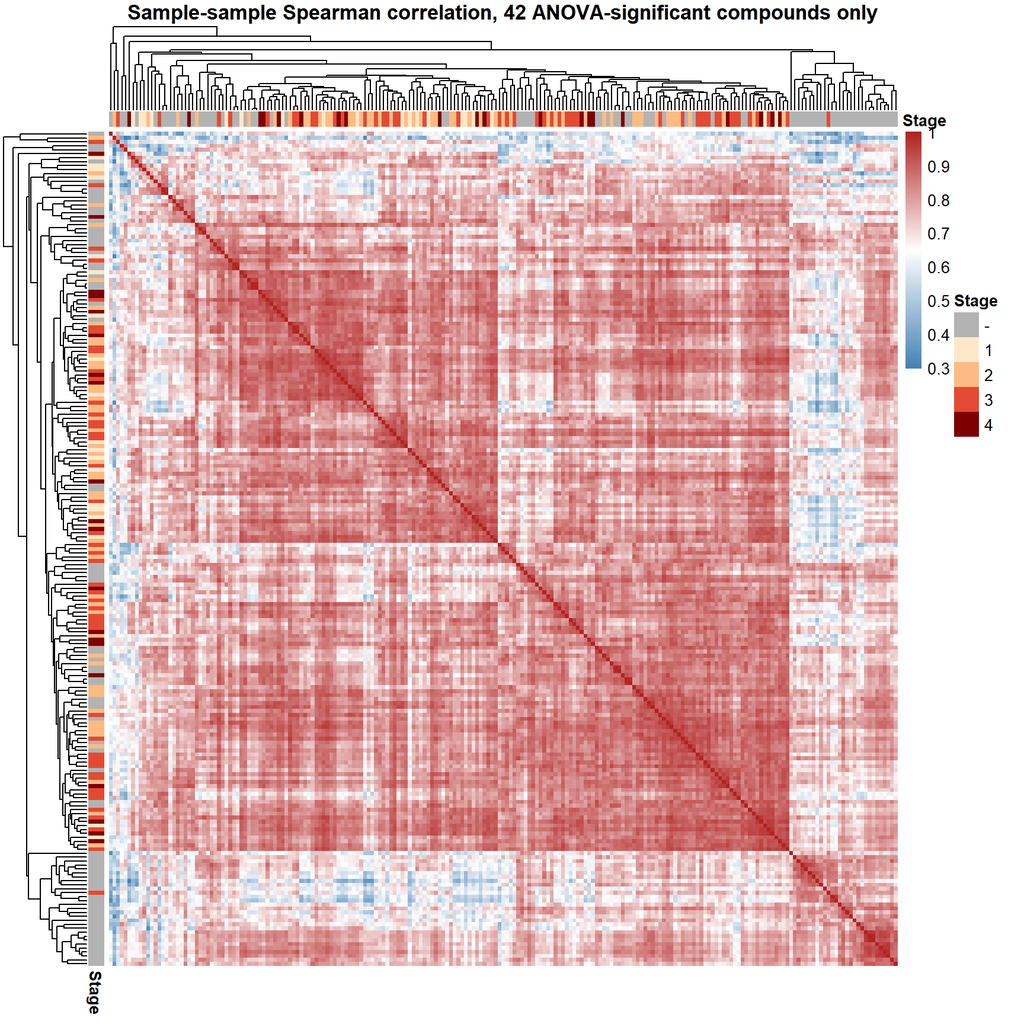

```r
log_wide_sig <- log_wide[rownames(log_wide) %in% sig_compound_names, ]

sample_cor_sig <- cor(log_wide_sig, method = "spearman", use = "pairwise.complete.obs")
sample_dist_sig <- as.dist(1 - sample_cor_sig)
stage_annotation_sig <- stage_annotation[colnames(sample_cor_sig), , drop = FALSE]

pheatmap(
  sample_cor_sig,
  clustering_distance_rows = sample_dist_sig,
  clustering_distance_cols = sample_dist_sig,
  clustering_method = "average",
  annotation_row = stage_annotation_sig,
  annotation_col = stage_annotation_sig,
  annotation_colors = stage_colors,
  show_rownames = FALSE,
  show_colnames = FALSE,
  main = "Sample-sample Spearman correlation, 42 ANOVA-significant compounds only",
  color = colorRampPalette(c("steelblue", "white", "firebrick"))(100),
  breaks = seq(min(sample_cor_sig), 1, length.out = 101)
)
```

```r
cor_long_sig <- as.data.frame(sample_cor_sig) |>
  rownames_to_column("sample_a") |>
  pivot_longer(-sample_a, names_to = "sample_b", values_to = "r") |>
  filter(sample_a != sample_b) |>
  left_join(stage_annotation_sig |> rownames_to_column("sample_a") |> rename(stage_a = Stage), by = "sample_a") |>
  left_join(stage_annotation_sig |> rownames_to_column("sample_b") |> rename(stage_b = Stage), by = "sample_b") |>
  mutate(pair_type = ifelse(stage_a == stage_b, "same stage", "different stage"))

cor_long_sig |>
  group_by(pair_type) |>
  summarise(mean_r = mean(r), median_r = median(r), n_pairs = n(), .groups = "drop")
```

```
## # A tibble: 2 × 4
##   pair_type       mean_r median_r n_pairs
##   <chr>            <dbl>    <dbl>   <int>
## 1 different stage  0.768    0.783   33374
## 2 same stage       0.784    0.797   10936
```

```r
# Collapse to Control vs Cancer to test the specific signal found by ANOVA/Tukey
cor_long_sig |>
  mutate(
    group_a = ifelse(stage_a == "-", "Control", "Cancer"),
    group_b = ifelse(stage_b == "-", "Control", "Cancer"),
    diag_pair_type = paste(pmin(group_a, group_b), pmax(group_a, group_b), sep = " - ")
  ) |>
  group_by(diag_pair_type) |>
  summarise(mean_r = mean(r), median_r = median(r), n_pairs = n(), .groups = "drop")
```

```
## # A tibble: 3 × 4
##   diag_pair_type    mean_r median_r n_pairs
##   <chr>              <dbl>    <dbl>   <int>
## 1 Cancer - Cancer    0.808    0.824   18090
## 2 Cancer - Control   0.743    0.756   20520
## 3 Control - Control  0.757    0.766    5700
```

## Mean sample-sampel correlations by stage pair (42 sig metabolites)

```r
stage_matrix_full <- cor_long |>
  group_by(stage_a, stage_b) |>
  summarise(mean_r = mean(r), .groups = "drop") |>
  pivot_wider(names_from = stage_b, values_from = mean_r)

stage_matrix_sig <- cor_long_sig |>
  group_by(stage_a, stage_b) |>
  summarise(mean_r = mean(r), .groups = "drop") |>
  pivot_wider(names_from = stage_b, values_from = mean_r)

cat("All 99 compounds:\n")
```

```
## All 99 compounds:
```

```r
print(stage_matrix_full)
```

```
## # A tibble: 5 × 6
##   stage_a   `-`   `1`   `2`   `3`   `4`
##   <fct>   <dbl> <dbl> <dbl> <dbl> <dbl>
## 1 -       0.780 0.771 0.780 0.779 0.769
## 2 1       0.771 0.814 0.807 0.807 0.805
## 3 2       0.780 0.807 0.811 0.812 0.805
## 4 3       0.779 0.807 0.812 0.814 0.804
## 5 4       0.769 0.805 0.805 0.804 0.802
```

```r
cat("\n42 ANOVA-significant compounds:\n")
```

```
##
## 42 ANOVA-significant compounds:
```

```r
print(stage_matrix_sig)
```

```
## # A tibble: 5 × 6
##   stage_a   `-`   `1`   `2`   `3`   `4`
##   <fct>   <dbl> <dbl> <dbl> <dbl> <dbl>
## 1 -       0.757 0.732 0.747 0.743 0.745
## 2 1       0.732 0.809 0.799 0.789 0.809
## 3 2       0.747 0.799 0.815 0.809 0.818
## 4 3       0.743 0.789 0.809 0.810 0.810
## 5 4       0.745 0.809 0.818 0.810 0.835
```

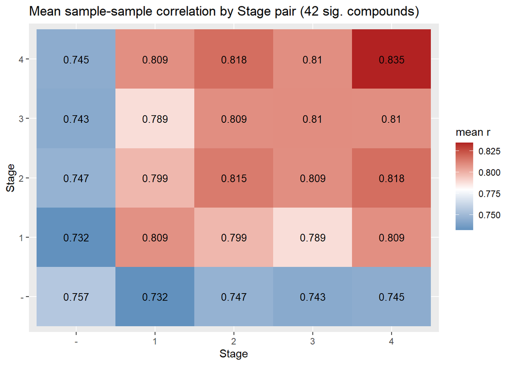

```r
stage_matrix_sig_long <- cor_long_sig |>
  group_by(stage_a, stage_b) |>
  summarise(mean_r = mean(r), .groups = "drop")

ggplot(stage_matrix_sig_long, aes(x = stage_a, y = stage_b, fill = mean_r)) +
  geom_tile() +
  geom_text(aes(label = round(mean_r, 3)), size = 3.5) +
  scale_fill_gradient2(low = "steelblue", mid = "white", high = "firebrick", midpoint = 0.78) +
  labs(title = "Mean sample-sample correlation by Stage pair (42 sig. compounds)",
       x = "Stage", y = "Stage", fill = "mean r")
```

## PCA scores: does PC1 vs PC2 separate by Stage?

The correlation analyses above show Control separates from Cancer, but individual cancer Stages do not separate from each other. We check whether a PCA scores plot shows the same pattern – both across all 86 complete-case compounds, and restricted to the 42 ANOVA-significant compounds (where the Stage/Diagnosis signal is concentrated).

`log_wide` (built above for the compound-compound correlation analysis) still has 13 compounds with at least one missing value; `prcomp()` requires complete data, so we restrict to the 86 compounds with no missing values rather than imputing here.

```r
complete_compounds <- lcms_long_log |>
  group_by(Compound) |>
  summarise(any_na = any(is.na(log_abundance)), .groups = "drop") |>
  filter(!any_na) |>
  pull(Compound)

length(complete_compounds)
```

```
## [1] 86
```

```r
log_wide_complete <- log_wide[rownames(log_wide) %in% complete_compounds, ]

pca_fit <- prcomp(t(log_wide_complete), scale. = TRUE)

pca_scores <- as.data.frame(pca_fit$x[, 1:2]) |>
  rownames_to_column("sample_id") |>
  left_join(metadata_merged |> select(sample_id, Diagnosis, Stage) |> distinct(), by = "sample_id")
```

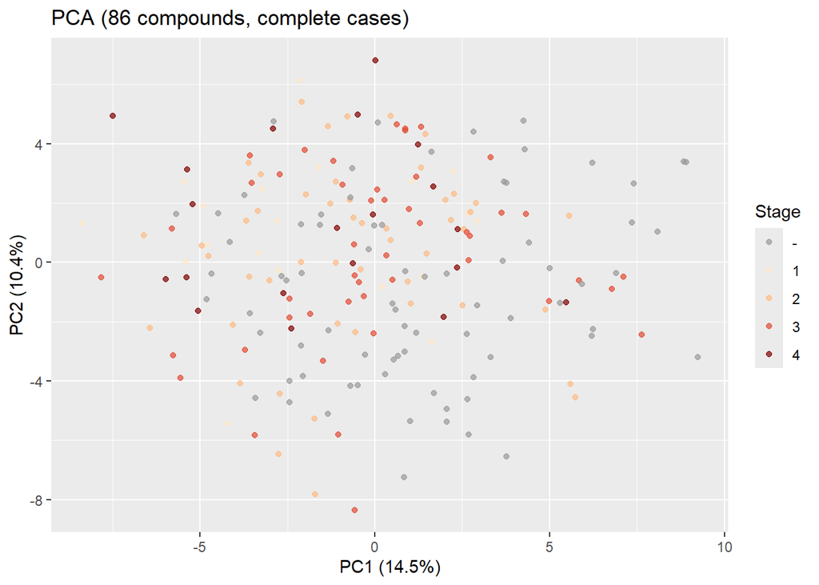

```r
var_pc1 <- round(summary(pca_fit)$importance[2, "PC1"] * 100, 1)
var_pc2 <- round(summary(pca_fit)$importance[2, "PC2"] * 100, 1)

stage_colors_vec <- c("-" = "grey60", "1" = "#fee8c8", "2" = "#fdbb84", "3" = "#e34a33", "4" = "#7f0000")

ggplot(pca_scores, aes(x = PC1, y = PC2, color = Stage)) +
  geom_point(alpha = 0.7) +
  scale_color_manual(values = stage_colors_vec) +
  labs(title = "PCA (86 compounds, complete cases)",
       x = paste0("PC1 (", var_pc1, "%)"), y = paste0("PC2 (", var_pc2, "%)"))
```

Using all 86 complete-case compounds, PC1/PC2 (together explaining only ~24.9% of variance) show no visible separation by Stage or Control – points of every Stage are thoroughly intermixed. This makes sense: most of these 86 compounds are not associated with Diagnosis/Stage, so their variance dilutes any real signal.

### Restricting to the 42 ANOVA-significant compounds

Missing values in 5 of the 42 compounds (57 values total, mostly Pentosidine) are imputed with the per-compound median for this PCA, since `prcomp()` requires complete data.

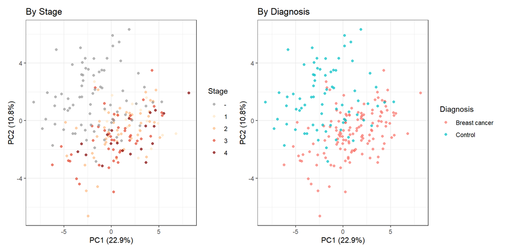

```r
library(tibble)
library(patchwork)

log_wide_sig_imputed <- t(apply(log_wide_sig, 1, function(x) {
  x[is.na(x)] <- median(x, na.rm = TRUE)
  x
}))

pca_fit_sig <- prcomp(t(log_wide_sig_imputed), scale. = TRUE)
var_pc1_sig <- round(summary(pca_fit_sig)$importance[2, "PC1"] * 100, 1)
var_pc2_sig <- round(summary(pca_fit_sig)$importance[2, "PC2"] * 100, 1)

pca_scores_sig <- as.data.frame(pca_fit_sig$x[, 1:2]) |>
  rownames_to_column("sample_id") |>
  left_join(metadata_merged |> select(sample_id, Diagnosis, Stage) |> distinct(), by = "sample_id")

p_pca_sig_stage <- ggplot(pca_scores_sig, aes(x = PC1, y = PC2, color = Stage)) +
  geom_point(alpha = 0.7) +
  scale_color_manual(values = stage_colors_vec) +
  labs(title = "By Stage", x = paste0("PC1 (", var_pc1_sig, "%)"), y = paste0("PC2 (", var_pc2_sig, "%)")) + theme_bw()

p_pca_sig_diag <- ggplot(pca_scores_sig, aes(x = PC1, y = PC2, color = Diagnosis)) +
  geom_point(alpha = 0.7) +
  labs(title = "By Diagnosis", x = paste0("PC1 (", var_pc1_sig, "%)"), y = paste0("PC2 (", var_pc2_sig, "%)")) +
  theme_bw()

p_pca_sig_stage | p_pca_sig_diag
```

```r
pca_scores_sig |>
  group_by(Diagnosis) |>
  summarise(mean_PC1 = mean(PC1), mean_PC2 = mean(PC2), n = n())
```

```
## # A tibble: 2 × 4
##   Diagnosis     mean_PC1 mean_PC2     n
##   <chr>            <dbl>    <dbl> <int>
## 1 Breast cancer    0.996   -0.850   135
## 2 Control         -1.77     1.51     76
```

```r
pca_scores_sig |>
  filter(Diagnosis == "Breast cancer") |>
  group_by(Stage) |>
  summarise(mean_PC1 = mean(PC1), mean_PC2 = mean(PC2), n = n())
```

```
## # A tibble: 4 × 4
##   Stage mean_PC1 mean_PC2     n
##   <fct>    <dbl>    <dbl> <int>
## 1 1        2.39     0.126    19
## 2 2        0.812   -0.803    49
## 3 3        0.263   -1.19     47
## 4 4        1.84    -1.10     20
```

Restricted to the 42 significant compounds, a pattern emerges: Control samples occupy mostly positive PC2 (mean PC2 = 1.51) while cancer samples skew negative (mean PC2 = -0.85) – visible as Control (grey/teal) points concentrating in the upper region of the plot. This is consistent with the Control-vs-cancer signal detected by ANOVA/Tukey and the sample-correlation analysis. However, among cancer cases, Stages 1-4 do **not** separate from each other – their mean PC1/PC2 values overlap substantially (e.g. Stage 3 mean PC2 = -1.19 vs. Stage 4 mean PC2 = -1.10) and points of all four Stages are intermixed within the “cancer” region. This matches every prior analysis: the detectable signal in this dataset is Control vs. Cancer, not Stage progression.

### Which compounds drive the PC2 (Control-vs-Cancer) separation?

```r
loadings_sig <- as.data.frame(pca_fit_sig$rotation[, 1:2]) |>
  rownames_to_column("Compound") |>
  rename(loading_PC1 = PC1, loading_PC2 = PC2) |>
  arrange(desc(abs(loading_PC2)))

loadings_sig |> select(Compound, loading_PC1, loading_PC2) |> head(15)
```

```
##                   Compound   loading_PC1 loading_PC2
## 1        Phenyllactic acid -0.1161757614   0.2638919
## 2                Glutamine  0.1380863541  -0.2505740
## 3                   Lysine  0.1104008080  -0.2346597
## 4  Sphingosine 1-phosphate  0.1954050423  -0.2244201
## 5      Dodecanoylcarnitine  0.2623794125   0.2207917
## 6        Bisnorcholic acid  0.1898496694  -0.2207712
## 7              Pentosidine -0.1046221794   0.2168917
## 8        Octanoylcarnitine  0.2533414044   0.2073008
## 9             Oxaloacetate -0.0857280761   0.2020419
## 10   Glycerophosphocholine -0.1114644866   0.2018017
## 11       Hexanoylcarnitine  0.2528075940   0.1929025
## 12             Quinic acid  0.0292525828   0.1897909
## 13  3-Indolepropionic acid -0.0009284318  -0.1874156
## 14            Progesterone  0.2508115054   0.1871403
## 15       Decanoylcarnitine  0.2663102849   0.1793737
```

To confirm these loadings correspond to a real Control-vs-Cancer difference (and not just an artifact of the rotation), we compare each top compound’s actual mean log2-abundance by Diagnosis.

```r
top_pc2_compounds <- loadings_sig |> slice_head(n = 15) |> pull(Compound)

lcms_long_log |>
  filter(Compound %in% top_pc2_compounds) |>
  group_by(Compound, Diagnosis) |>
  summarise(mean_log_abundance = mean(log_abundance, na.rm = TRUE), .groups = "drop") |>
  pivot_wider(names_from = Diagnosis, values_from = mean_log_abundance) |>
  mutate(higher_in = ifelse(`Breast cancer` > Control, "Cancer", "Control")) |>
  left_join(loadings_sig |> select(Compound, loading_PC2), by = "Compound") |>
  arrange(desc(abs(loading_PC2))) |>
  print()
```

```
## # A tibble: 15 × 5
##    Compound                `Breast cancer` Control higher_in loading_PC2
##    <chr>                             <dbl>   <dbl> <chr>           <dbl>
##  1 Phenyllactic acid                 -6.12   -3.87 Control         0.264
##  2 Glutamine                         -1.56   -2.35 Cancer         -0.251
##  3 Lysine                            -2.70   -3.65 Cancer         -0.235
##  4 Sphingosine 1-phosphate           -4.45   -4.99 Cancer         -0.224
##  5 Dodecanoylcarnitine               -4.74   -4.97 Cancer          0.221
##  6 Bisnorcholic acid                 -6.72   -7.26 Cancer         -0.221
##  7 Pentosidine                      -10.8    -6.69 Control         0.217
##  8 Octanoylcarnitine                 -5.15   -5.53 Cancer          0.207
##  9 Oxaloacetate                      -3.27   -3.17 Control         0.202
## 10 Glycerophosphocholine             -3.69   -2.09 Control         0.202
## 11 Hexanoylcarnitine                 -6.24   -6.59 Cancer          0.193
## 12 Quinic acid                       -2.01   -1.81 Control         0.190
## 13 3-Indolepropionic acid            -7.00   -8.14 Cancer         -0.187
## 14 Progesterone                      -6.30   -6.68 Cancer          0.187
## 15 Decanoylcarnitine                 -3.67   -4.32 Cancer          0.179
```

The top PC2 loadings are dominated by **Phenyllactic acid** and **Pentosidine** (both higher in Control) and **Glutamine**, **Lysine**, and **Sphingosine 1-phosphate** (all higher in Cancer), along with several medium-chain acylcarnitines (Dodecanoyl-, Octanoyl-, Hexanoyl-, Decanoylcarnitine). Loading sign broadly tracks actual Control-vs-Cancer direction for most of these compounds, but not perfectly (e.g. Dodecanoylcarnitine’s positive loading doesn’t match its higher-in-Cancer direction) – expected in a multivariate rotation where a compound’s PC2 contribution reflects its correlation with *all* other compounds jointly, not just its own univariate Control-vs-Cancer difference. For a purely univariate ranking of Control-vs-Cancer effects, the ANOVA/Tukey results earlier in this document are the more direct reference.

### Plotting compounds driving PC2 separation

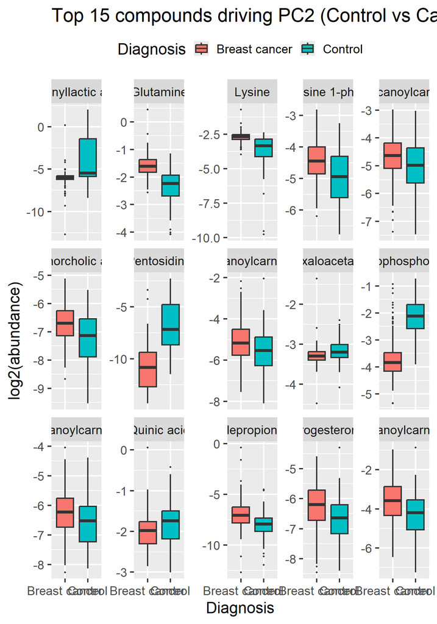

```r
#library(forcats)

plot_data <- lcms_long_log |>
  filter(Compound %in% top_pc2_compounds) |>
  mutate(Compound = fct_relevel(Compound, top_pc2_compounds))

ggplot(plot_data, aes(x = Diagnosis, y = log_abundance, fill = Diagnosis)) +
  geom_boxplot(outlier.size = 0.8) +
  facet_wrap(~Compound, scales = "free_y", ncol = 5) +
  labs(title = "Top 15 compounds driving PC2 (Control vs Cancer separation)",
       x = "Diagnosis", y = "log2(abundance)") +
  theme_gray(base_size = 18) +
  theme(legend.position = "top")
```

appropriate given the non-normality documented earlier) per compound, BH-corrected across these 15 tests.

```r
library(rstatix)
```

```r
library(ggpubr)

plot_data <- lcms_long_log |>
  filter(Compound %in% top_pc2_compounds) |>
  mutate(Compound = fct_relevel(Compound, top_pc2_compounds))

stat_test <- plot_data |>
  group_by(Compound) |>
  wilcox_test(log_abundance ~ Diagnosis) |>
  adjust_pvalue(method = "BH") |>
  add_significance("p.adj") |>
  add_xy_position(x = "Diagnosis", fun = "max", step.increase = 0.08)

stat_test |> select(Compound, group1, group2, p, p.adj, p.adj.signif)
```

```
## # A tibble: 15 × 6
##    Compound                group1        group2         p    p.adj p.adj.signif
##    <fct>                   <chr>         <chr>      <dbl>    <dbl> <chr>
##  1 Phenyllactic acid       Breast cancer Control 2.85e-12 8.54e-12 ****
##  2 Glutamine               Breast cancer Control 0        0        ****
##  3 Lysine                  Breast cancer Control 3.33e-15 1.25e-14 ****
##  4 Sphingosine 1-phosphate Breast cancer Control 1.60e- 5 3.42e- 5 ****
##  5 Dodecanoylcarnitine     Breast cancer Control 3.59e- 2 3.59e- 2 *
##  6 Bisnorcholic acid       Breast cancer Control 8.46e- 5 1.59e- 4 ***
##  7 Pentosidine             Breast cancer Control 6.67e-19 3.33e-18 ****
##  8 Octanoylcarnitine       Breast cancer Control 1.32e- 2 1.41e- 2 *
##  9 Oxaloacetate            Breast cancer Control 3.88e- 4 5.29e- 4 ***
## 10 Glycerophosphocholine   Breast cancer Control 1.21e-24 9.07e-24 ****
## 11 Hexanoylcarnitine       Breast cancer Control 4.32e- 3 4.98e- 3 **
## 12 Quinic acid             Breast cancer Control 1.27e- 3 1.58e- 3 **
## 13 3-Indolepropionic acid  Breast cancer Control 3.14e- 8 7.86e- 8 ****
## 14 Progesterone            Breast cancer Control 2.36e- 4 3.54e- 4 ***
## 15 Decanoylcarnitine       Breast cancer Control 1.08e- 4 1.80e- 4 ***
```

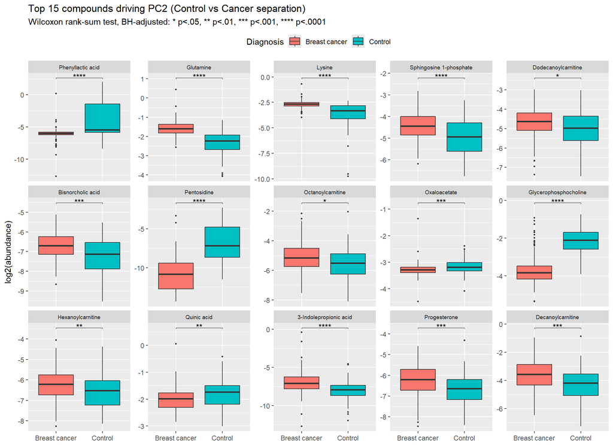

```r
ggplot(plot_data, aes(x = Diagnosis, y = log_abundance, fill = Diagnosis)) +
  geom_boxplot(outlier.size = 0.8) +
  stat_pvalue_manual(stat_test, label = "p.adj.signif", tip.length = 0.01, hide.ns = FALSE) +
  facet_wrap(~Compound, scales = "free_y", ncol = 5) +
  labs(title = "Top 15 compounds driving PC2 (Control vs Cancer separation)",
       subtitle = "Wilcoxon rank-sum test, BH-adjusted: * p<.05, ** p<.01, *** p<.001, **** p<.0001",
       x = NULL, y = "log2(abundance)") +
  theme(legend.position = "top", strip.text = element_text(size = 7))
```

## Mapping significant metabolites onto KEGG pathways

The 42 ANOVA-significant compounds all have a significant Control-vs-Stage Tukey pair (i.e. the Control-vs-cancer-driven set identified earlier is identical to the full ANOVA-significant set). We map these 42 compound names onto KEGG compound IDs, then onto KEGG pathways, using `KEGGREST`. (`MetaboAnalystR` was considered for this step but skipped – it requires a heavy, GitHub-only install with many Bioconductor dependencies, whereas KEGGREST’s `compound`/`pathway` REST endpoints cover what we need directly.)

Name resolution is not fully automatic: many compound names in this dataset don’t exactly match KEGG’s canonical synonyms (e.g. KEGG stores “Butyrylcarnitine” as “O-Butanoylcarnitine”, “Homocysteic acid” as “L-Homocysteic acid”). We first try an exact case-insensitive match against KEGG’s synonym list (stripping common prefixes like `O-`/`L-`/`D-`/`N6-`), then manually verify a handful of remaining names against candidate KEGG entries.

```r
library(KEGGREST)

control_vs_cancer_sig <- tukey_results |>
  filter(grepl("--$", contrast), adj.p.value < 0.05) |>
  distinct(Compound) |>
  pull(Compound)

length(control_vs_cancer_sig)  # identical to the 42 ANOVA-significant compounds
```

```
## [1] 42
```

```r
strip_prefixes <- function(x) {
  x <- tolower(x)
  x <- gsub("^(o-|l-|d-|n6-|n-|\\(r\\)-|\\(s\\)-)", "", x)
  trimws(x)
}

resolve_kegg <- function(name) {
  hits <- tryCatch(keggFind("compound", name), error = function(e) NULL)
  if (is.null(hits) || length(hits) == 0) return(NA_character_)
  target <- strip_prefixes(name)
  for (i in seq_along(hits)) {
    syns <- str_split(hits[i], ";")[[1]] |> str_trim() |> strip_prefixes()
    if (any(syns == target)) return(names(hits)[i])
  }
  # fall back to unstripped exact match
  for (i in seq_along(hits)) {
    syns <- str_split(hits[i], ";")[[1]] |> str_trim()
    if (any(tolower(syns) == tolower(name))) return(names(hits)[i])
  }
  NA_character_
}

kegg_map <- tibble(Compound = control_vs_cancer_sig) |>
  mutate(kegg_id_raw = map_chr(Compound, resolve_kegg))

# A handful of names needed manual verification against candidate KEGG
# entries (e.g. confirming "Phenyllactic acid" -> C05607 "Phenyllactate",
# not the superficially similar but biologically distinct C01207
# "3-(3,4-Dihydroxyphenyl)lactate" that a naive fuzzy match would suggest).
manual_matches <- c(
  "Octanoylcarnitine" = "C02838",
  "Butyrylcarnitine" = "C02862",
  "Propionylcarnitine" = "C03017",
  "Decanoylcarnitine" = "C03299",
  "Homocysteic acid" = "C16511",
  "Phenyllactic acid" = "C05607",
  "6-Phosphogluconic acid" = "C00345",
  "Delta-hydroxylysine" = "C16741"
)

kegg_map_final <- kegg_map |>
  mutate(kegg_id = ifelse(is.na(kegg_id_raw), manual_matches[Compound], kegg_id_raw)) |>
  select(Compound, kegg_id)

kegg_map_final |> count(matched = !is.na(kegg_id))
```

```
## # A tibble: 2 × 2
##   matched     n
##   <lgl>   <int>
## 1 FALSE      13
## 2 TRUE       29
```

```r
kegg_map_final |> filter(is.na(kegg_id))
```

```
## # A tibble: 13 × 2
##    Compound                        kegg_id
##    <chr>                           <chr>
##  1 3-Indolepropionic acid          <NA>
##  2 3-Pyridylacetic acid            <NA>
##  3 4_8 dimethylnonanoyl carnitine  <NA>
##  4 Bisnorcholic acid               <NA>
##  5 Dodecanoylcarnitine             <NA>
##  6 Hexanoylcarnitine               <NA>
##  7 Linoleyl carnitine              <NA>
##  8 oleoylcarnitine                 <NA>
##  9 Pentosidine                     <NA>
## 10 Stearoylcarnitine               <NA>
## 11 Succinyladenosine               <NA>
## 12 Tetradecanoylcarnitine          <NA>
## 13 trans-Hexadec-2-enoyl carnitine <NA>
```

29 of 42 compounds (69%) resolve to a KEGG compound ID. The 13 that don’t were checked against multiple synonym variants each and genuinely have no entry in KEGG’s compound database – mostly longer-chain acylcarnitines (Dodecanoyl-, Hexanoyl-, Stearoyl-, Tetradecanoylcarnitine, Linoleyl carnitine, oleoylcarnitine, trans-Hexadec-2-enoyl carnitine), the free form of Pentosidine (only a protein-bound form, `[Protein]-pentosidine`, exists in KEGG), and a few others (3-Indolepropionic acid, 3-Pyridylacetic acid, Bisnorcholic acid, Succinyladenosine, 4,8-dimethylnonanoyl carnitine). This is a genuine coverage gap in KEGG (it curates core metabolic pathway compounds rather than the full space of lipid/exotic metabolite species), not a search failure.

### Which pathways do the mapped compounds belong to?

Generic KEGG overview/global maps (e.g. “Metabolic pathways”, “Biosynthesis of secondary metabolites”) are excluded, since they aren’t specific enough to be informative.

```r
EXCLUDE <- c(
  "map01100", "map01110", "map01120", "map01200", "map01210", "map01230",
  "map01240", "map01250", "map01220", "map01310", "map01320",
  "map01060", "map01061", "map01062", "map01063", "map01064", "map01065",
  "map01066", "map01070", "map00996", "map00997", "map00998", "map00999",
  "map00975", "map02010", "map02020"
)

mapped_ids <- kegg_map_final |> filter(!is.na(kegg_id)) |> pull(kegg_id)
pathway_links <- keggLink("pathway", mapped_ids)

path_names_raw <- keggList("pathway", "hsa")
path_names <- tibble(
  path = paste0("map", substr(names(path_names_raw), 4, 8)),
  pathway_name = sub(" - Homo sapiens.*", "", path_names_raw)
) |> distinct(path, .keep_all = TRUE)

pathway_df <- tibble(
  cpd = sub("^cpd:", "", names(pathway_links)),
  path = sub("^path:", "", pathway_links)
) |>
  filter(!path %in% EXCLUDE) |>
  left_join(kegg_map_final |> rename(cpd = kegg_id), by = "cpd") |>
  left_join(path_names, by = "path") |>
  mutate(pathway_name = ifelse(is.na(pathway_name), path, pathway_name))

pathway_summary <- pathway_df |>
  group_by(path, pathway_name) |>
  summarise(
    n_compounds = n_distinct(Compound),
    compounds = paste(sort(unique(Compound)), collapse = ", "),
    .groups = "drop"
  ) |>
  arrange(desc(n_compounds))

pathway_summary |> select(pathway_name, n_compounds, compounds)
```

```
## # A tibble: 83 × 3
##    pathway_name                                n_compounds compounds
##    <chr>                                             <int> <chr>
##  1 Glyoxylate and dicarboxylate metabolism               4 4-Hydroxy-2-oxogluta…
##  2 D-Amino acid metabolism                               3 Glutamine, Lysine, O…
##  3 Neuroactive ligand-receptor interaction               3 Homocysteic acid, Pr…
##  4 Steroid hormone biosynthesis                          2 Androstenedione, Pro…
##  5 Pyrimidine metabolism                                 2 Glutamine, Uracil
##  6 Alanine, aspartate and glutamate metabolism           2 Glutamine, Oxaloacet…
##  7 Lysine degradation                                    2 Delta-hydroxylysine,…
##  8 beta-Alanine metabolism                               2 Carnosine, Uracil
##  9 Glycerophospholipid metabolism                        2 Choline, Glycerophos…
## 10 Nicotinate and nicotinamide metabolism                2 3-Succinoylpyridine,…
## # ℹ 73 more rows
```

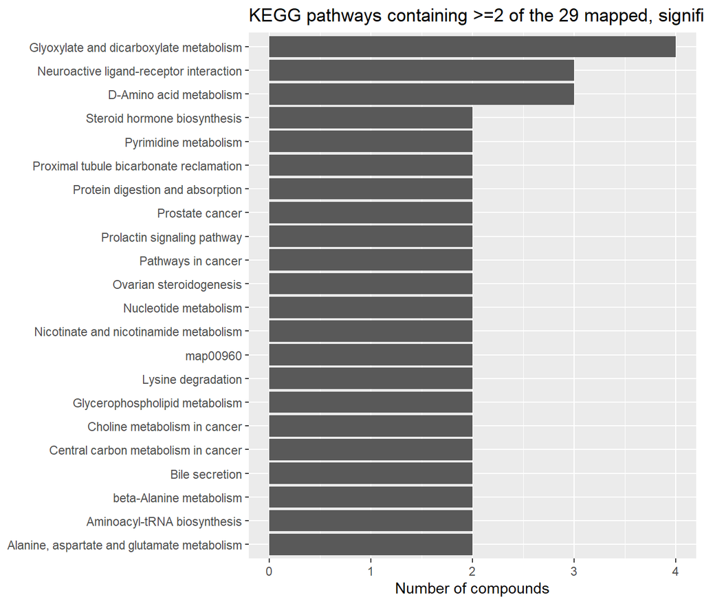

```r
plot_df <- pathway_summary |> filter(n_compounds >= 2) |> arrange(n_compounds)

ggplot(plot_df, aes(x = n_compounds, y = reorder(pathway_name, n_compounds))) +
  geom_col() +
  labs(title = "KEGG pathways containing >=2 of the 29 mapped, significant compounds",
       x = "Number of compounds", y = NULL)
```

The mapped compounds are spread thinly across many pathways – most pathways contain only 1-2 of our compounds, reflecting that these 29 metabolites span diverse core metabolic processes (amino acid, lipid, nucleotide, and steroid metabolism) rather than concentrating in one pathway. A few pathways of note given breast-cancer relevance: **Choline metabolism in cancer**, **Pathways in cancer**, and **Prostate cancer** each contain 2 compounds, and **Steroid hormone biosynthesis** / **Ovarian steroidogenesis** (Androstenedione, Progesterone) reflect the hormone-related compounds in the panel. This mapping is descriptive; it does not yet test whether any pathway is significantly *over-represented* relative to chance (that would require a formal enrichment test, e.g. a hypergeometric test against a defined background, as a natural next step).

### Formal hypergeometric enrichment test

As discussed earlier, the background (“population”) for this test is the **99 compounds actually measured on this platform** – not the full KEGG compound database – since testing against the full KEGG universe would overstate significance for pathways that happen to overlap with what this assay can detect. We map all 99 compounds to KEGG IDs (reusing the manually-verified IDs from the 42 significant compounds above; the remaining ~57 non-significant compounds use automated matching only, since they don’t need the same scrutiny as the compounds driving our conclusions).

```r
all_99_compounds <- unique(lcms_long$Compound)

kegg_map_all <- tibble(Compound = all_99_compounds) |>
  mutate(kegg_id_raw = map_chr(Compound, resolve_kegg)) |>
  mutate(kegg_id = ifelse(is.na(kegg_id_raw) & Compound %in% names(manual_matches),
                           manual_matches[Compound], kegg_id_raw)) |>
  select(Compound, kegg_id)

# Prefer the manually-verified IDs for the 42 significant compounds
kegg_map_universe <- kegg_map_all |>
  left_join(kegg_map_final |> rename(kegg_id_verified = kegg_id), by = "Compound") |>
  mutate(kegg_id = coalesce(kegg_id_verified, kegg_id)) |>
  select(Compound, kegg_id)

sum(!is.na(kegg_map_universe$kegg_id))  # of 99 total
```

```
## [1] 61
```

61 of 99 measured compounds (62%) resolve to a KEGG ID – a similar hit rate to the 42-compound panel. We retrieve pathway links for this full background set, then run a one-sided hypergeometric test per pathway: given `n_population` background compounds with a pathway annotation, `n_sample` of which are our significant compounds, and `K` background compounds in a given pathway, what’s the probability of seeing `k` or more significant compounds in that pathway by chance?

```r
bg_ids <- kegg_map_universe |> filter(!is.na(kegg_id)) |> pull(kegg_id)
bg_pathway_links <- keggLink("pathway", bg_ids)

bg_pathway_df <- tibble(
  cpd = sub("^cpd:", "", names(bg_pathway_links)),
  path = sub("^path:", "", bg_pathway_links)
) |>
  filter(!path %in% EXCLUDE) |>
  left_join(kegg_map_universe |> rename(cpd = kegg_id), by = "cpd")

n_population <- bg_pathway_df |> distinct(Compound) |> nrow()
n_sample <- pathway_df |> distinct(Compound) |> nrow()

bg_counts <- bg_pathway_df |>
  group_by(path) |>
  summarise(K = n_distinct(Compound), .groups = "drop")

hit_counts <- pathway_df |>
  group_by(path, pathway_name) |>
  summarise(k = n_distinct(Compound),
            hit_compounds = paste(sort(unique(Compound)), collapse = ", "),
            .groups = "drop")

enrichment <- hit_counts |>
  left_join(bg_counts, by = "path") |>
  mutate(
    p_value = phyper(k - 1, K, n_population - K, n_sample, lower.tail = FALSE),
    p_adj = p.adjust(p_value, method = "BH")
  ) |>
  arrange(p_value)

n_sample      # significant, pathway-annotated compounds tested
```

```
## [1] 22
```

```r
n_population  # background, pathway-annotated compounds tested
```

```
## [1] 49
```

```r
enrichment |> select(pathway_name, k, K, p_value, p_adj, hit_compounds) |> head(10)
```

```
## # A tibble: 10 × 6
##    pathway_name                              k     K p_value p_adj hit_compounds
##    <chr>                                 <int> <int>   <dbl> <dbl> <chr>
##  1 Neuroactive ligand-receptor interact…     3     3  0.0836 0.654 Homocysteic …
##  2 Pyrimidine metabolism                     2     2  0.196  0.654 Glutamine, U…
##  3 beta-Alanine metabolism                   2     2  0.196  0.654 Carnosine, U…
##  4 map00960                                  2     2  0.196  0.654 Lysine, Phen…
##  5 Ovarian steroidogenesis                   2     2  0.196  0.654 Androstenedi…
##  6 Proximal tubule bicarbonate reclamat…     2     2  0.196  0.654 Glutamine, O…
##  7 Pathways in cancer                        2     2  0.196  0.654 Androstenedi…
##  8 Prostate cancer                           2     2  0.196  0.654 Androstenedi…
##  9 Choline metabolism in cancer              2     2  0.196  0.654 Choline, Gly…
## 10 Glyoxylate and dicarboxylate metabol…     4     6  0.240  0.654 4-Hydroxy-2-…
```

**No pathway reaches significance after BH correction** – the best nominal p-value (Neuroactive ligand-receptor interaction, 3/3 hit compounds) is 0.084, which becomes 0.65 after adjusting for the 83 pathways tested. This null result should be taken at face value rather than over-interpreted from the raw ranking: only 22 of the 42 significant compounds have any non-generic KEGG pathway annotation, tested against a 49-compound background – a very small sample for a hypergeometric test to have meaningful power. This mirrors a common limitation in untargeted metabolomics pathway analysis: incomplete database coverage of measured compounds constrains not just compound identification but also downstream enrichment power, and the platform-specific background (however more statistically appropriate than the full KEGG universe) further reduces the population size available for testing. The pathway *mapping* above remains useful as a descriptive/hypothesis-generating summary; it should not be read as demonstrating statistically-supported pathway-level dysregulation.

### Sensitivity check: full KEGG compound database as background

For contrast, we rerun the identical test but swap the background for the **entire KEGG compound universe** (all compounds appearing in any non-generic pathway map) instead of the 99 measured compounds. This is the default in many enrichment tools, but it is the **less conservative, less defensible** choice here: it implicitly assumes our assay could have detected any KEGG compound, which is false for a targeted panel, and it therefore tends to overstate significance.

```r
bg_all_raw <- keggLink("pathway", "compound")

bg_all <- tibble(
  cpd  = sub("^cpd:", "", names(bg_all_raw)),
  path = sub("^path:", "", bg_all_raw)
) |>
  filter(grepl("^map", path), !path %in% EXCLUDE)

n_population_full <- bg_all |> distinct(cpd) |> nrow()

bg_counts_full <- bg_all |>
  group_by(path) |>
  summarise(K = n_distinct(cpd), .groups = "drop")

enrichment_full <- hit_counts |>
  left_join(bg_counts_full, by = "path") |>
  mutate(
    p_value = phyper(k - 1, K, n_population_full - K, n_sample, lower.tail = FALSE),
    p_adj   = p.adjust(p_value, method = "BH")
  ) |>
  arrange(p_value)

n_population_full                          # full-KEGG background size
```

```
## [1] 6286
```

```r
sum(enrichment_full$p_adj < 0.05)          # pathways significant after BH
```

```
## [1] 11
```

```r
enrichment_full |> select(pathway_name, k, K, p_value, p_adj, hit_compounds) |> head(15)
```

```
## # A tibble: 15 × 6
##    pathway_name                            k     K p_value   p_adj hit_compounds
##    <chr>                               <int> <int>   <dbl>   <dbl> <chr>
##  1 Glyoxylate and dicarboxylate metab…     4    67 7.46e-5 0.00620 4-Hydroxy-2-…
##  2 Prolactin signaling pathway             2    11 6.31e-4 0.0162  Androstenedi…
##  3 Choline metabolism in cancer            2    11 6.31e-4 0.0162  Choline, Gly…
##  4 Neuroactive ligand-receptor intera…     3    53 7.78e-4 0.0162  Homocysteic …
##  5 Prostate cancer                         2    15 1.19e-3 0.0198  Androstenedi…
##  6 Proximal tubule bicarbonate reclam…     2    17 1.54e-3 0.0208  Glutamine, O…
##  7 D-Amino acid metabolism                 3    70 1.75e-3 0.0208  Glutamine, L…
##  8 Ovarian steroidogenesis                 2    24 3.08e-3 0.0320  Androstenedi…
##  9 Alanine, aspartate and glutamate m…     2    28 4.18e-3 0.0386  Glutamine, O…
## 10 Pathways in cancer                      2    31 5.11e-3 0.0411  Androstenedi…
## 11 beta-Alanine metabolism                 2    32 5.44e-3 0.0411  Carnosine, U…
## 12 Central carbon metabolism in cancer     2    37 7.23e-3 0.0500  Glutamine, O…
## 13 Breast cancer                           1     3 1.05e-2 0.0601  Progesterone
## 14 Protein digestion and absorption        2    47 1.15e-2 0.0601  Glutamine, L…
## 15 Oocyte meiosis                          1     4 1.39e-2 0.0601  Progesterone
```

Against the full KEGG background (6286 compounds), the **conclusion flips: 11 pathways now pass BH correction at p_adj < 0.05**, including Glyoxylate and dicarboxylate metabolism, Choline metabolism in cancer, Prolactin signaling, Prostate cancer, D-amino acid metabolism, Ovarian steroidogenesis, Alanine/aspartate/glutamate metabolism, and Pathways in cancer. The *hit compounds* are identical to the descriptive mapping – what changed is only the denominator. With ~6,300 background compounds instead of 49, finding 2-4 of our compounds concentrated in a small pathway looks far more surprising by chance, so the p-values shrink dramatically.

This side-by-side is the whole point of the background-choice discussion: the *same data* yields “nothing significant” or “11 significant pathways” depending entirely on the reference set. The platform-restricted background (previous section) is the more honest choice for a targeted panel, so these 11 hits should be read as **suggestive, not confirmatory** – the full-KEGG result is best treated as an upper bound on what enrichment might look like with a fully-annotated, untargeted platform.

## Predictive modeling: classifying Control vs. Cancer with PLS-DA

Every analysis above points to a Control-vs-Cancer signal (not stage). Here we test how well that signal supports *classification* of an individual sample as Control or Breast cancer, using PLS-DA (partial least squares discriminant analysis) – a standard supervised method for high-dimensional, correlated metabolomics predictors.

**Avoiding feature-selection leakage.** The 42 “significant” compounds were chosen using an ANOVA on the *full* dataset. If we simply fed those into a classifier and evaluated on a held-out subset, the test set would have already influenced feature selection, inflating apparent performance. To avoid this, we split first, then re-run the ANOVA/BH selection **using only the training set**, so the test set plays no role in choosing predictors.

### Train/test split and leakage-free feature selection

```r
library(tidymodels)
library(plsmod)
```

```r
library(tibble)

# Wide design matrix: all 99 compounds (log2) x samples, outcome = Diagnosis
modeling_df <- lcms_long_log |>
  select(Compound, sample_id, log_abundance) |>
  pivot_wider(names_from = Compound, values_from = log_abundance) |>
  left_join(metadata_merged |> select(sample_id, Diagnosis) |> distinct(),
            by = "sample_id") |>
  mutate(Diagnosis = factor(Diagnosis, levels = c("Control", "Breast cancer"))) |>
  column_to_rownames("sample_id")

set.seed(4127)
split <- initial_split(modeling_df, strata = Diagnosis)
train <- training(split)
test  <- testing(split)

# Re-select significant compounds using TRAINING DATA ONLY
train_ids <- rownames(train)
anova_results_train <- lcms_long_log |>
  filter(sample_id %in% train_ids) |>
  group_by(Compound) |>
  nest() |>
  mutate(
    model = map(data, ~ aov(log_abundance ~ Stage, data = .x)),
    tidy_model = map(model, broom::tidy)
  ) |>
  select(Compound, tidy_model) |>
  unnest(tidy_model) |>
  filter(term == "Stage") |>
  ungroup() |>
  mutate(p_adj_BH = p.adjust(p.value, method = "BH"))

predictor_cols <- anova_results_train |> filter(p_adj_BH < 0.05) |> pull(Compound)
length(predictor_cols)  # training-only significant compounds
```

```
## [1] 27
```

```r
train_final <- train[, c(predictor_cols, "Diagnosis")]
test_final  <- test[, c(predictor_cols, "Diagnosis")]
```

Training-only selection yields 27 compounds (fewer than the 42 from the full data, as expected with a smaller sample), all of which are a subset of the original 42.

### Cross-validation setup and null baseline

```r
set.seed(6183)
folds <- vfold_cv(train_final, v = 10, strata = Diagnosis)

metrics_class <- metric_set(roc_auc, accuracy, brier_class)

# Null baseline: always predicts the majority class
null_wf <- workflow() |>
  add_recipe(recipe(Diagnosis ~ ., data = train_final) |>
               step_impute_median(all_numeric_predictors())) |>
  add_model(null_model(mode = "classification") |> set_engine("parsnip"))

null_res <- fit_resamples(null_wf, resamples = folds, metrics = metrics_class)
collect_metrics(null_res) |> select(.metric, mean, std_err)
```

```
## # A tibble: 3 × 3
##   .metric      mean std_err
##   <chr>       <dbl>   <dbl>
## 1 accuracy    0.640 0.00626
## 2 brier_class 0.231 0.00173
## 3 roc_auc     0.5   0
```

The class split is 64% cancer / 36% control, so the null model reaches 0.64 accuracy but ROC AUC of exactly 0.50 – it has no discriminative ability, which is the bar PLS-DA must clear.

### PLS-DA: tuning the number of components

Missing values (Pentosidine, Phenyllactic acid) are median-imputed and predictors normalized inside the recipe, so both are refit within each resample fold. The only hyperparameter is the number of latent components.

```r
pls_wf <- workflow() |>
  add_recipe(
    recipe(Diagnosis ~ ., data = train_final) |>
      step_impute_median(all_numeric_predictors()) |>
      step_normalize(all_numeric_predictors())
  ) |>
  add_model(pls(num_comp = tune()) |> set_engine("mixOmics") |> set_mode("classification"))

set.seed(7321)
pls_tune <- tune_grid(
  pls_wf,
  resamples = folds,
  grid = tibble(num_comp = 1:10),
  metrics = metrics_class
)

collect_metrics(pls_tune) |>
  filter(.metric == "roc_auc") |>
  select(num_comp, mean, std_err) |>
  arrange(desc(mean))
```

```
## # A tibble: 10 × 3
##    num_comp  mean std_err
##       <int> <dbl>   <dbl>
##  1        2 0.985  0.0118
##  2        3 0.983  0.0117
##  3        6 0.983  0.0134
##  4        4 0.983  0.0122
##  5        5 0.982  0.0128
##  6        9 0.978  0.0134
##  7        7 0.978  0.0151
##  8        8 0.977  0.0156
##  9       10 0.977  0.0149
## 10        1 0.928  0.0222
```

ROC AUC peaks at `num_comp = 2` (CV mean 0.985) and is essentially flat for 2-6 components, so we take the most parsimonious choice, 2 components.

### Final model: held-out test-set evaluation

```r
pls_final_wf <- finalize_workflow(pls_wf, tibble(num_comp = 2))

cv_metrics <- collect_metrics(pls_tune) |>
  filter(num_comp == 2) |>
  select(.metric, cv_mean = mean, cv_std_err = std_err)

pls_fit <- fit(pls_final_wf, data = train_final)

test_pred <- test_final |>
  bind_cols(predict(pls_fit, test_final, type = "prob")) |>
  bind_cols(predict(pls_fit, test_final, type = "class"))

test_metrics <- bind_rows(
  roc_auc(test_pred, truth = Diagnosis, .pred_Control),
  accuracy(test_pred, truth = Diagnosis, .pred_class),
  brier_class(test_pred, truth = Diagnosis, .pred_Control)
) |>
  select(.metric, test = .estimate)

cv_metrics |> left_join(test_metrics, by = ".metric")
```

```
## # A tibble: 3 × 4
##   .metric     cv_mean cv_std_err  test
##   <chr>         <dbl>      <dbl> <dbl>
## 1 accuracy      0.950    0.0204  0.962
## 2 brier_class   0.125    0.00386 0.126
## 3 roc_auc       0.985    0.0118  0.952
```

```r
conf_mat(test_pred, truth = Diagnosis, estimate = .pred_class)
```

```
##                Truth
## Prediction      Control Breast cancer
##   Control            17             0
##   Breast cancer       2            34
```

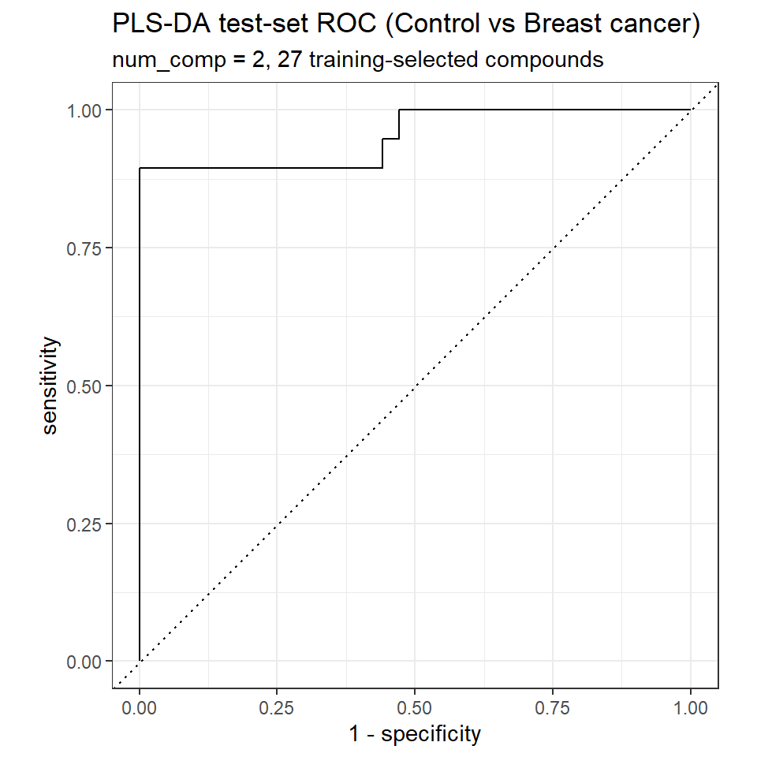

```r
roc_curve(test_pred, truth = Diagnosis, .pred_Control) |>
  autoplot() +
  labs(title = "PLS-DA test-set ROC (Control vs Breast cancer)",
       subtitle = "num_comp = 2, 27 training-selected compounds")
```

The final model generalizes well: **test-set ROC AUC 0.95, accuracy 0.96, Brier score 0.13**, versus the null baseline’s AUC of 0.50 and accuracy 0.64. Test metrics closely track the cross-validation estimates (CV AUC 0.985), indicating little overfitting. On the 53 held-out samples, all 34 cancer cases were correctly classified (perfect sensitivity) and 17 of 19 controls were correct (2 controls misclassified as cancer).

**Caveats.** (1) The held-out test evaluation is honest with respect to the *test* set – it played no role in feature selection or fitting – but the cross-validation AUC is mildly optimistic because feature selection was done once on the whole training set rather than re-run inside each CV fold; the test-set number is the estimate to trust. (2) This classifies Control vs. Cancer, the signal we established is real; it does **not** predict stage, consistent with every earlier result. (3) With only 19 controls in the test set, the specificity estimate (17/19 = 0.89) has a wide confidence interval, so the two control misclassifications shouldn’t be over-interpreted.

## Stage-specific models: predicting each Cancer Stage vs. Control

Every analysis above (ANOVA/Tukey, sample-sample correlation, PCA) shows the same pattern: each cancer Stage separates from Control, but Stages 1-4 do not separate well from *each other*. A single 5-way classifier (Control vs. Stage 1 vs. 2 vs. 3 vs. 4) would be fighting that structure. Instead we build **four independent binary PLS-DA models** – Stage 1 vs Control, Stage 2 vs Control, Stage 3 vs Control, Stage 4 vs Control – each trained and evaluated only on Control samples plus that one cancer stage, using Healthy Control as the shared negative class throughout.

Each model repeats the same leakage-free procedure as the Control-vs-Cancer PLS-DA above: split into train/test first, then re-run ANOVA + BH selection **using only that model’s training samples** to pick predictors, then tune a PLS-DA classifier’s number of components. Folds are reduced from 10 to 5 because some per-stage training sets are small (Stage 1 has only 19 cancer cases in total).

```r
library(tidymodels)
library(plsmod)
library(broom)
library(tibble)

fit_stage_vs_control <- function(stage_level, seed_split = 4127, seed_cv = 6183, seed_tune = 7321) {

  df_stage <- lcms_long_log |>
    filter(Stage %in% c("-", stage_level)) |>
    select(Compound, sample_id, log_abundance) |>
    pivot_wider(names_from = Compound, values_from = log_abundance) |>
    left_join(metadata_merged |> select(sample_id, Stage) |> distinct(), by = "sample_id") |>
    mutate(Stage = factor(ifelse(Stage == "-", "Control", paste0("Stage", stage_level)),
                           levels = c("Control", paste0("Stage", stage_level)))) |>
    column_to_rownames("sample_id")

  set.seed(seed_split)
  split <- initial_split(df_stage, strata = Stage)
  train <- training(split)
  test  <- testing(split)

  # Re-select significant compounds using TRAINING DATA ONLY for this stage's contrast
  train_ids <- rownames(train)
  anova_train <- lcms_long_log |>
    filter(sample_id %in% train_ids) |>
    mutate(Stage = droplevels(Stage)) |>
    group_by(Compound) |>
    nest() |>
    mutate(
      model = map(data, ~ aov(log_abundance ~ Stage, data = .x)),
      tidy_model = map(model, broom::tidy)
    ) |>
    select(Compound, tidy_model) |>
    unnest(tidy_model) |>
    filter(term == "Stage") |>
    ungroup() |>
    mutate(p_adj_BH = p.adjust(p.value, method = "BH"))

  predictor_cols <- anova_train |> filter(p_adj_BH < 0.05) |> pull(Compound)
  # Fallback to nominal p < .05 if BH leaves nothing (guards the smallest stages)
  if (length(predictor_cols) == 0) {
    predictor_cols <- anova_train |> filter(p.value < 0.05) |> pull(Compound)
  }

  train_final <- train[, c(predictor_cols, "Stage")]
  test_final  <- test[, c(predictor_cols, "Stage")]

  set.seed(seed_cv)
  folds <- vfold_cv(train_final, v = 5, strata = Stage)
  metrics_class <- metric_set(roc_auc, accuracy, brier_class)
  max_comp <- min(10, length(predictor_cols))

  pls_wf <- workflow() |>
    add_recipe(
      recipe(Stage ~ ., data = train_final) |>
        step_impute_median(all_numeric_predictors()) |>
        step_normalize(all_numeric_predictors())
    ) |>
    add_model(pls(num_comp = tune()) |> set_engine("mixOmics") |> set_mode("classification"))

  set.seed(seed_tune)
  pls_tune <- tune_grid(
    pls_wf, resamples = folds,
    grid = tibble(num_comp = 1:max_comp),
    metrics = metrics_class
  )

  best_comp <- collect_metrics(pls_tune) |>
    filter(.metric == "roc_auc") |>
    slice_max(mean, n = 1, with_ties = FALSE) |>
    pull(num_comp)

  pls_final_wf <- finalize_workflow(pls_wf, tibble(num_comp = best_comp))
  pls_fit <- fit(pls_final_wf, data = train_final)

  test_pred <- test_final |>
    bind_cols(predict(pls_fit, test_final, type = "prob")) |>
    bind_cols(predict(pls_fit, test_final, type = "class"))

  stage_label <- paste0("Stage", stage_level)
  test_metrics <- bind_rows(
    roc_auc(test_pred, truth = Stage, .pred_Control),
    accuracy(test_pred, truth = Stage, .pred_class),
    brier_class(test_pred, truth = Stage, .pred_Control)
  ) |>
    mutate(stage = stage_label)

  list(
    stage = stage_label,
    n_train = nrow(train_final), n_test = nrow(test_final),
    n_predictors = length(predictor_cols), predictors = predictor_cols,
    best_comp = best_comp, test_metrics = test_metrics, test_pred = test_pred,
    conf_mat = conf_mat(test_pred, truth = Stage, estimate = .pred_class)
  )
}

stage_results <- map(c("1", "2", "3", "4"), fit_stage_vs_control)
names(stage_results) <- paste0("Stage", c("1", "2", "3", "4"))
```

### Test-set performance by stage

```r
map_dfr(stage_results, ~ tibble(
  stage = .x$stage, n_train = .x$n_train, n_test = .x$n_test,
  n_predictors = .x$n_predictors, num_comp = .x$best_comp
))
```

```
## # A tibble: 4 × 5
##   stage  n_train n_test n_predictors num_comp
##   <chr>    <int>  <int>        <int>    <int>
## 1 Stage1      71     24           24        4
## 2 Stage2      93     32           18        3
## 3 Stage3      92     31           14        5
## 4 Stage4      72     24           19        2
```

```r
map_dfr(stage_results, ~ .x$test_metrics) |>
  select(stage, .metric, .estimate) |>
  pivot_wider(names_from = .metric, values_from = .estimate)
```

```
## # A tibble: 4 × 4
##   stage  roc_auc accuracy brier_class
##   <chr>    <dbl>    <dbl>       <dbl>
## 1 Stage1   0.989    0.917       0.118
## 2 Stage2   0.870    0.875       0.162
## 3 Stage3   1        1           0.117
## 4 Stage4   1        0.917       0.128
```

```r
walk(stage_results, ~ {
  cat("\n", .x$stage, "vs Control:\n")
  print(.x$conf_mat)
})
```

```
##
##  Stage1 vs Control:
##           Truth
## Prediction Control Stage1
##    Control      18      1
##    Stage1        1      4
##
##  Stage2 vs Control:
##           Truth
## Prediction Control Stage2
##    Control      19      4
##    Stage2        0      9
##
##  Stage3 vs Control:
##           Truth
## Prediction Control Stage3
##    Control      19      0
##    Stage3        0     12
##
##  Stage4 vs Control:
##           Truth
## Prediction Control Stage4
##    Control      17      0
##    Stage4        2      5
```

All four models beat the Control-vs-Cancer null baseline (AUC 0.50) by a wide margin, but performance is not uniform: **Stage 1** (24 predictors, 4 components) reaches AUC 0.99 / accuracy 0.92 (22/24, with one misclassification in each direction on a test set of only 5 Stage 1 cases); **Stage 2** (18 predictors, 3 components) is the weakest of the four at AUC 0.87 / accuracy 0.88 (28/32), missing 4 of 13 Stage 2 test cases as false negatives while Control specificity stays perfect; **Stage 3** (14 predictors, 5 components) achieves perfect test-set separation (AUC 1.00 / accuracy 1.00, 31/31); and **Stage 4** (19 predictors, 2 components) reaches AUC 1.00 / accuracy 0.92 (22/24), correctly classifying all 5 Stage 4 test cases (perfect sensitivity) but misclassifying 2 of 19 controls as Stage 4.

### ROC curves

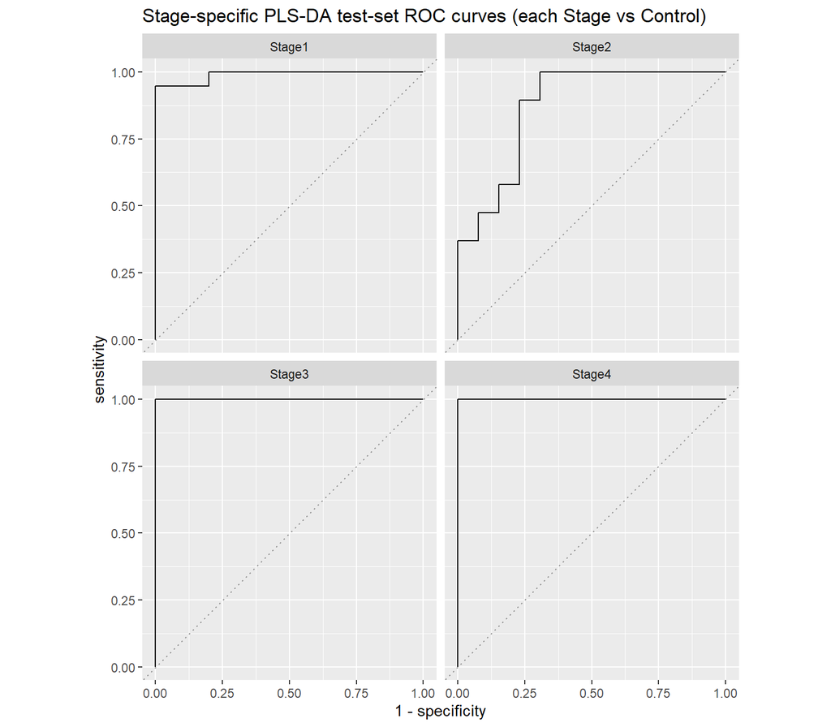

```r
roc_data <- map_dfr(stage_results, function(x) {
  roc_curve(x$test_pred, truth = Stage, .pred_Control) |> mutate(stage = x$stage)
})

ggplot(roc_data, aes(x = 1 - specificity, y = sensitivity)) +
  geom_path() +
  geom_abline(lty = 3, color = "grey60") +
  facet_wrap(~stage) +
  coord_equal() +
  labs(title = "Stage-specific PLS-DA test-set ROC curves (each Stage vs Control)")
```

### Which compounds recur across stage-specific models?

```r
predictor_sets <- map(stage_results, "predictors")

predictor_overlap <- tibble(Compound = unique(unlist(predictor_sets))) |>
  mutate(
    Stage1 = Compound %in% predictor_sets$Stage1,
    Stage2 = Compound %in% predictor_sets$Stage2,
    Stage3 = Compound %in% predictor_sets$Stage3,
    Stage4 = Compound %in% predictor_sets$Stage4,
    n_stages = Stage1 + Stage2 + Stage3 + Stage4
  ) |>
  arrange(desc(n_stages))

predictor_overlap |> filter(n_stages >= 3)
```

```
## # A tibble: 12 × 6
##    Compound                Stage1 Stage2 Stage3 Stage4 n_stages
##    <chr>                   <lgl>  <lgl>  <lgl>  <lgl>     <int>
##  1 Glutamine               TRUE   TRUE   TRUE   TRUE          4
##  2 Glycerophosphocholine   TRUE   TRUE   TRUE   TRUE          4
##  3 Pentosidine             TRUE   TRUE   TRUE   TRUE          4
##  4 Sphingosine 1-phosphate TRUE   TRUE   TRUE   TRUE          4
##  5 3-Indolepropionic acid  TRUE   TRUE   TRUE   FALSE         3
##  6 Bilirubin               TRUE   TRUE   FALSE  TRUE          3
##  7 Bisnorcholic acid       TRUE   TRUE   FALSE  TRUE          3
##  8 Butyrylcarnitine        TRUE   FALSE  TRUE   TRUE          3
##  9 Linoleyl carnitine      TRUE   TRUE   FALSE  TRUE          3
## 10 Lysine                  TRUE   TRUE   TRUE   FALSE         3
## 11 Phenyllactic acid       FALSE  TRUE   TRUE   TRUE          3
## 12 Propionylcarnitine      FALSE  TRUE   TRUE   TRUE          3
```

Four compounds – **Glutamine, Glycerophosphocholine, Pentosidine, and Sphingosine 1-phosphate** – are selected as significant predictors in *every* stage-specific model. These are the same compounds flagged earlier as top PC2 loadings driving the global Control-vs-Cancer separation, which is a useful consistency check: the signal identified independently at every stage converges on the same small set of “always-on” Control-vs-Cancer markers, on top of a larger set of stage-specific compounds that vary from model to model.

**Caveats.** (1) Each stage model is trained and evaluated independently; the four classifiers were never trained to distinguish stages from one another, so a genuinely new sample could in principle score “positive” under more than one stage model at once – these are four separate Stage-vs-Control screens, not a single mutually-exclusive multi-way classifier. (2) Per-stage test sets are small, especially for Stage 1 and Stage 4 (5 cancer cases each in the test set); Stage 2 and Stage 3 have more test cases (13 and 12 respectively) and give more stable estimates. (3) As with the global Control-vs-Cancer model, `num_comp` was tuned once per stage rather than re-tuned inside each CV fold, so cross-validation metrics would be mildly optimistic – the held-out test metrics reported above are the ones to trust. (4) Stage 2 shows the weakest separation from Control (AUC 0.87 vs. ~0.99-1.00 for the other three stages) despite having the largest cancer sample size of the four – worth flagging as a stage that may need more samples or additional predictors to resolve confidently, rather than concluding it is inherently less metabolically distinct from Control.

## Receptor data

```r
receptor <- metadata_csv |>
  transmute(
    sample_id = `Sample name`,
    Diagnosis,
    ER  = case_when(ER == "1" ~ "ER+",  ER == "-" ~ "ER-",  TRUE ~ NA_character_),
    PR  = case_when(PR == "1" ~ "PR+",  PR == "-" ~ "PR-",  TRUE ~ NA_character_),
    HER2 = case_when(`HER-2 neu` == "1" ~ "HER2+", `HER-2 neu` == "-" ~ "HER2-", TRUE ~ NA_character_)
  ) |>
  filter(Diagnosis == "Breast cancer")

nrow(receptor)
```

```
## [1] 135
```

```r
receptor |> count(ER)
```

```
## # A tibble: 3 × 2
##   ER        n
##   <chr> <int>
## 1 ER+      75
## 2 ER-      53
## 3 <NA>      7
```

```r
receptor |> count(PR)
```

```
## # A tibble: 3 × 2
##   PR        n
##   <chr> <int>
## 1 PR+      62
## 2 PR-      66
## 3 <NA>      7
```

```r
receptor |> count(HER2)
```

```
## # A tibble: 3 × 2
##   HER2      n
##   <chr> <int>
## 1 HER2+    43
## 2 HER2-    74
## 3 <NA>     18
```

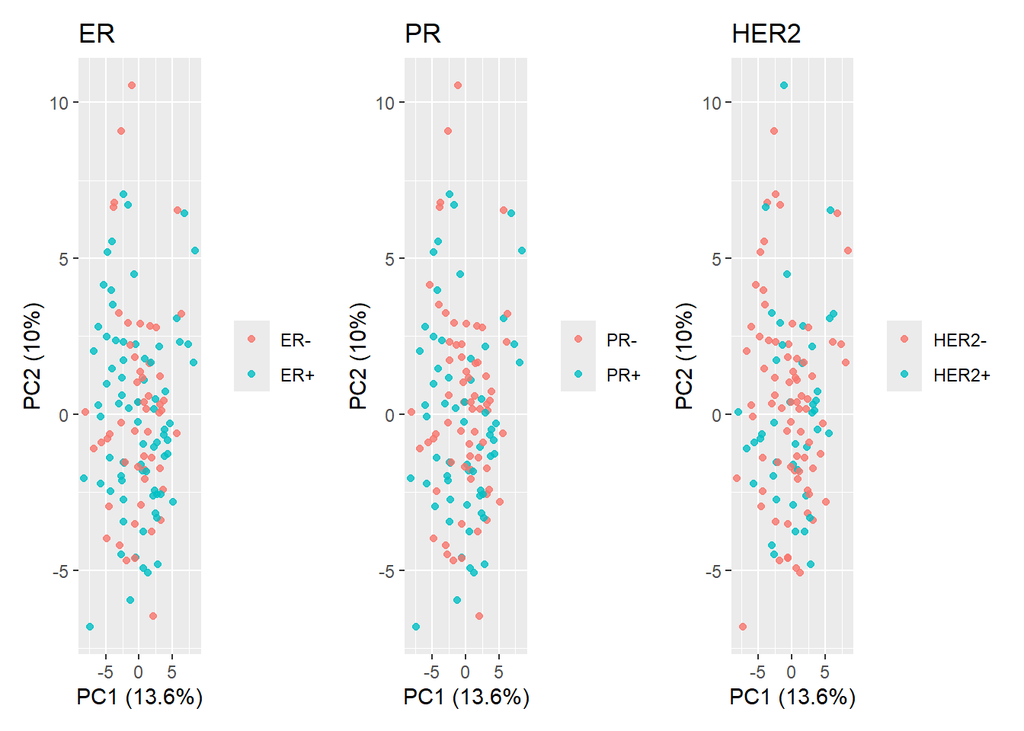

```r
cancer_ids <- receptor$sample_id
lw_cancer <- log_wide[, cancer_ids]
lw_cancer_imp <- t(apply(lw_cancer, 1, function(x) { x[is.na(x)] <- median(x, na.rm = TRUE); x }))

pca_cancer <- prcomp(t(lw_cancer_imp), scale. = TRUE)
vp1 <- round(summary(pca_cancer)$importance[2, "PC1"] * 100, 1)
vp2 <- round(summary(pca_cancer)$importance[2, "PC2"] * 100, 1)

scores_cancer <- as.data.frame(pca_cancer$x[, 1:2]) |>
  rownames_to_column("sample_id") |>
  left_join(receptor, by = "sample_id")

mk <- function(colvar) {
  d <- scores_cancer |> filter(!is.na(.data[[colvar]]))
  ggplot(d, aes(PC1, PC2, color = .data[[colvar]])) +
    geom_point(alpha = 0.8) +
    labs(title = colvar, x = paste0("PC1 (", vp1, "%)"), y = paste0("PC2 (", vp2, "%)"), color = NULL)
}

mk("ER") | mk("PR") | mk("HER2")
```

No gross separation by ER, PR, or HER-2 status appears in the top two principal components — the groups are thoroughly intermixed in all three panels. But I’d be cautious reading too much into this: PC1/PC2 capture only 23.6% of the variance across all 99 compounds, and recall the Control-vs-Cancer signal itself was invisible in the full-compound PCA and only emerged once we restricted to the significant compounds and looked at PC2. So this plot argues against a large, global receptor effect, but it does not rule out differences in individual compounds.

## Adding clinical covariates: receptor status, Age, and BMI

The receptor panels above test ER/PR/HER2 one at a time and don’t account for Age or BMI, both of which can independently shift metabolite levels and so could confound a raw receptor-status comparison. Here we (1) collapse ER/PR/HER2 into a single, better-powered **Receptor+ vs Triple-negative** contrast, and (2) fit a covariate-adjusted linear regression per compound – `log_abundance ~ HR_status + Age + BMI` – so the receptor-status effect is estimated *after* controlling for Age and BMI.

`metadata_merged` already carries the raw `ER`, `PR`, `HER-2 neu`, `Age (BOD-OD)` (age at blood draw – the biologically relevant age here, as opposed to `Age (now)`, which is a data-collection-year artifact for Control rows) and `BMI` columns; they were never dropped by the earlier `select(-ends_with(...))` step. `lcms_long_log` inherits them too, so before joining our derived covariates we select down to just `Compound`, `sample_id`, `log_abundance` – otherwise the join produces `BMI.x`/`BMI.y`-style duplicates instead of a single usable `BMI` column.

```r
receptor_full <- metadata_merged |>
  filter(Diagnosis == "Breast cancer") |>
  transmute(
    sample_id,
    ER   = case_when(ER == "1" ~ "ER+",  ER == "-" ~ "ER-",  TRUE ~ NA_character_),
    PR   = case_when(PR == "1" ~ "PR+",  PR == "-" ~ "PR-",  TRUE ~ NA_character_),
    HER2 = case_when(`HER-2 neu` == "1" ~ "HER2+", `HER-2 neu` == "-" ~ "HER2-", TRUE ~ NA_character_),
    Age  = `Age (BOD-OD)`,
    BMI
  ) |>
  mutate(
    HR_status = case_when(
      ER == "ER+" | PR == "PR+" | HER2 == "HER2+" ~ "Receptor+",
      ER == "ER-" & PR == "PR-" & HER2 == "HER2-" ~ "Triple-negative",
      TRUE ~ NA_character_
    ),
    HR_status = factor(HR_status, levels = c("Receptor+", "Triple-negative"))
  ) |>
  filter(!is.na(HR_status), !is.na(Age), !is.na(BMI))

nrow(receptor_full)
```

```
## [1] 119
```

```r
receptor_full |> count(HR_status)
```

```
## # A tibble: 2 × 2
##   HR_status           n
##   <fct>           <int>
## 1 Receptor+          95
## 2 Triple-negative    24
```

```r
lcms_receptor <- lcms_long_log |>
  select(Compound, sample_id, log_abundance) |>
  inner_join(receptor_full, by = "sample_id")
```

### Linear regression: a single compound worked example

```r
glutamine_fit <- lm(log_abundance ~ HR_status + Age + BMI,
                     data = lcms_receptor |> filter(Compound == "Glutamine"))
summary(glutamine_fit)
```

```
##
## Call:
## lm(formula = log_abundance ~ HR_status + Age + BMI, data = filter(lcms_receptor,
##     Compound == "Glutamine"))
##
## Residuals:
##      Min       1Q   Median       3Q      Max
## -0.94545 -0.25508 -0.04398  0.21402  1.91090
##
## Coefficients:
##                           Estimate Std. Error t value Pr(>|t|)
## (Intercept)              -2.003890   0.257364  -7.786 3.32e-12 ***
## HR_statusTriple-negative -0.112609   0.097973  -1.149    0.253
## Age                       0.005820   0.003771   1.543    0.125
## BMI                       0.004823   0.004831   0.999    0.320
## ---
## Signif. codes:  0 '***' 0.001 '**' 0.01 '*' 0.05 '.' 0.1 ' ' 1
##
## Residual standard error: 0.4043 on 115 degrees of freedom
## Multiple R-squared:  0.05235,    Adjusted R-squared:  0.02763
## F-statistic: 2.118 on 3 and 115 DF,  p-value: 0.1018
```

For Glutamine, none of the three covariates reach significance individually (HR status p = .25, Age p = .13, BMI p = .32), and the full model explains only 5% of variance (adjusted R² = 0.028) – Glutamine’s earlier Control-vs-Cancer signal doesn’t extend to a within-cancer receptor/age/BMI effect.

### Systematic per-compound regression, BH-corrected

```r
lm_results <- lcms_receptor |>
  group_by(Compound) |>
  nest() |>
  mutate(
    model = map(data, ~ lm(log_abundance ~ HR_status + Age + BMI, data = .x)),
    tidy_model = map(model, broom::tidy)
  ) |>
  select(Compound, tidy_model) |>
  unnest(tidy_model) |>
  ungroup()

hr_effect <- lm_results |>
  filter(term == "HR_statusTriple-negative") |>
  mutate(p_adj_BH = p.adjust(p.value, method = "BH")) |>
  arrange(p_adj_BH)

age_effect <- lm_results |>
  filter(term == "Age") |>
  mutate(p_adj_BH = p.adjust(p.value, method = "BH")) |>
  arrange(p_adj_BH)

bmi_effect <- lm_results |>
  filter(term == "BMI") |>
  mutate(p_adj_BH = p.adjust(p.value, method = "BH")) |>
  arrange(p_adj_BH)

cat("HR status -- significant (BH < .05):", sum(hr_effect$p_adj_BH < 0.05), "of 99\n")
```

```
## HR status -- significant (BH < .05): 0 of 99
```

```r
cat("Age       -- significant (BH < .05):", sum(age_effect$p_adj_BH < 0.05), "of 99\n")
```

```
## Age       -- significant (BH < .05): 9 of 99
```

```r
cat("BMI       -- significant (BH < .05):", sum(bmi_effect$p_adj_BH < 0.05), "of 99\n")
```

```
## BMI       -- significant (BH < .05): 0 of 99
```

```r
age_effect |> select(Compound, estimate, p.value, p_adj_BH) |> head(9)
```

```
## # A tibble: 9 × 4
##   Compound                          estimate    p.value p_adj_BH
##   <chr>                                <dbl>      <dbl>    <dbl>
## 1 Quinic acid                         0.0180 0.00000295 0.000293
## 2 trans-Hexadec-2-enoyl carnitine     0.0280 0.0000149  0.000739
## 3 Tetradecanoylcarnitine              0.0213 0.000101   0.00332
## 4 Androstenedione                     0.0290 0.000176   0.00349
## 5 Glycolaldehyde                      0.0252 0.000164   0.00349
## 6 6-Dehydrotestosterone glucuronide   0.0714 0.000311   0.00513
## 7 Hexanoylcarnitine                   0.0228 0.00129    0.0182
## 8 Thiamine                            0.0300 0.00173    0.0214
## 9 oleoylcarnitine                     0.0175 0.00408    0.0449
```

**Receptor status: 0 of 99 compounds** remain significant after BH correction – consistent with the PCA panels above showing no gross receptor-status separation, and now confirmed at the individual-compound level even after adjusting for Age and BMI. **BMI: 0 of 99** compounds survive correction either (a handful have nominal p < .01, e.g. 3-Indolepropionic acid, Phenyllactic acid, Succinyladenosine, but none withstand testing across 99 compounds). **Age is the one covariate with a real signal: 9 of 99 compounds** remain significant after BH correction, led by Quinic acid, *trans*-Hexadec-2-enoyl carnitine, Tetradecanoylcarnitine, Androstenedione, and Glycolaldehyde (all p_adj < .01) – an age-related metabolite signature independent of receptor status, worth keeping in mind as a potential confounder in any future model that doesn’t explicitly adjust for it.

### Repeating the receptor PCA with the collapsed HR+ / Triple-negative contrast

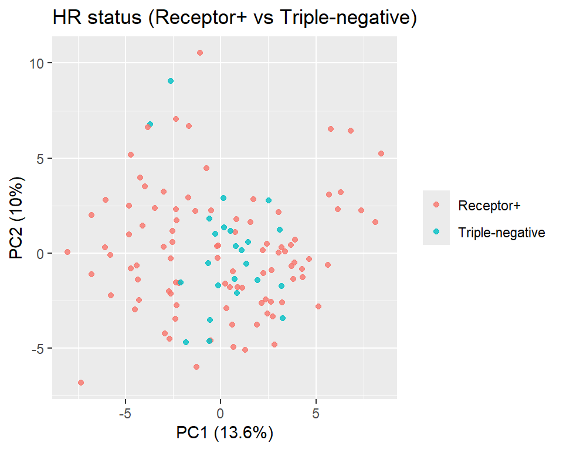

```r
scores_cancer_hr <- scores_cancer |>
  left_join(receptor_full |> select(sample_id, HR_status), by = "sample_id")

ggplot(scores_cancer_hr |> filter(!is.na(HR_status)), aes(PC1, PC2, color = HR_status)) +
  geom_point(alpha = 0.8) +
  labs(title = "HR status (Receptor+ vs Triple-negative)",
       x = paste0("PC1 (", vp1, "%)"), y = paste0("PC2 (", vp2, "%)"), color = NULL)
```

As with the three-way ER/PR/HER2 split, the collapsed HR+/Triple-negative groups are still thoroughly intermixed on PC1/PC2 – the better-powered contrast doesn’t reveal a global receptor-status structure the three-way split was missing. Combined with the per-compound regression above, receptor status looks like it has, at most, a small, compound-specific effect on this platform rather than a broad metabolic signature – unlike the clear Control-vs-Cancer separation established earlier in this document.

**Caveats.** (1) Three covariate terms were tested per compound (HR status, Age, BMI); each was BH-corrected across the 99 compounds independently for that term, not jointly across all ~297 tests, matching how each earlier single-factor analysis in this document was corrected. (2) The Triple-negative group is small (n = 24) relative to Receptor+ (n = 95), so the HR-status term has limited power to detect anything but a fairly large effect – absence of significance here is not strong evidence of *no* effect, just of no *detectable* one at this sample size. (3) `Age (BOD-OD)` (age at blood draw) was used rather than `Age (now)`, which is not usable for this purpose (it is populated with a collection year, not an age, for Control rows, and is a different, less relevant reference point even for cancer rows).